[**FMI**](http://fmi.unibuc.ro/ro/) 2019-2020

# Instrumente Statistice pentru Finanțe

# Regresie liniară

Aceste note de curs sunt destinate studenților de anul I de master de la Facultatea de Matematică și Informatică.

# 1 Introducere

Cuvântul “regresie” vine de la Sir Francis Galton (1822 - 1911) care, fiind interesat de problema transmiterii unui caracter ereditar de la părinți la copii, a strâns date despre înălțimea părinților și cea a copiilor lor ajunși adolescenți[^1]. Astfel a încercat să examineze relația dintre înălțimea copiilor și înălțimea medie a părinților (a ajustat diferențele naturale dintre sexe înmulțind înălțimea persoanelor de sex feminin cu un coeficient de 1.08).

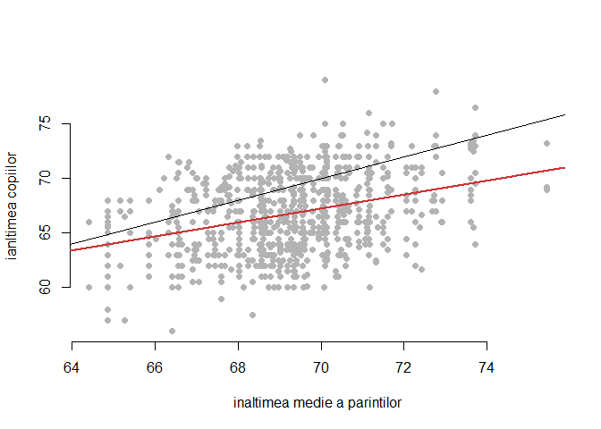

A observat că între înălțimea copiilor (ajunși la vârstă adultă) și înălțimea medie a părinților există o relație (aproximativ) liniară cu o pantă de 2/3 (mai exact 0.6411904). Având o pantă mai mică de $1$, Galton a tras concluzia că acei copii care provin din familii cu părinți foarte înalți (sau scunzi) sunt în general mai scunzi (înalți) decât părinții lor. Astfel, oricare ar fi situația (familii cu părinți înalți ori scunzi), înălțimea copiilor tinde spre media populației, ceea ce Galton a numit *regresie* spre medie. Cu alte cuvinte, Galton a studiat modul în care *variabila explicativă* $x$ = “înălțimea medie a părinților” influențează *variabila răspuns* $y$ = “înălțimea copiilor” și a propus, ținând cont de faptul că relația dintre cele două variabile nu este exact liniară ci depinde de erori aleatoare, următorul model

$$y = \beta_0 + \beta_1 x + \varepsilon$$

în care componenta sistematică $\beta_0 + \beta_1 x$ este liniară și $\varepsilon$ este eroarea aleatoare.

De manieră informală, un model explicativ este un model prin care o variabilă $\mathcal{Y}$ este exprimată ca o funcție de una sau mai multe variabile, numite în cele ce urmează explicative. De manieră formală, încercăm să modelăm efectul unei variabile sau a mai multor variabile explicative $x_1,\ldots, x_k$ asupra variabilei de interes $y$. Variabila $y$ se numește *variabilă răspuns* sau *variabilă dependentă* iar variabilele explicative se mai numesc și *covariabile*, *variabile independente* (termen pe care nu îl vom folosi), *factori* sau încă *regresori*. Într-un model de regresie, căutăm, de cele mai multe ori, să determinăm modul în care variabila răspuns evoluează, *în medie*, în funcție de variabilele explicative. O caracteristică principală a modelelor de regresie este că relația dintre $y$ și covariabile nu se exprimă ca o funcție deterministă $f(x_1,\ldots,x_k)$ ci prezintă erori aleatoare ceea ce sugerează că variabila răspuns este o variabilă aleatoare a cărei distribuție depinde de valorile variabilelor explicative. De exemplu, în cazul problemei lui Galton, chiar dacă știam cu exactitate care este înălțimea părinților nu puteam prezice exact înălțimea copiilor, ceea ce puteam face era să estimăm *înălțimea medie* a acestora și gradul de împrăștiere.

De manieră generală, modelul de regresie poate fi scris sub forma

$$y(x_1,\ldots,x_k) = f(x_1,\ldots,x_k) + \varepsilon(x_1,\ldots, x_k)$$

unde, membrul stâng arată dependența variabilei răspuns de variabilele explicative $y(x_1,\ldots,x_k)$ iar membrul drept este compus din doi termeni, *componenta sistematică* a modelului $f(x_1,\ldots,x_k)$ care prezintă influența covariabilelor asupra valorii medii a variabilei dependente ($\mathbb{E}[y(x_1,\ldots,x_k)] = f(x_1,\ldots,x_k)$) și *componenta aleatoare*, $\varepsilon(x_1,\ldots, x_k)$, numită și termen eroare care prezintă incertitudinea modelului. Cum $\mathbb{E}[y(x_1,\ldots,x_k)] = f(x_1,\ldots,x_k)$ avem că $\mathbb{E}[\varepsilon(x_1,\ldots, x_k)] = 0$. În modelul clasic de regresie vom presupune că termenul eroare nu depinde de covariabile, prin urmare $\varepsilon(x_1,\ldots, x_k) = \varepsilon$ și modelul se va rescrie sub forma

$$y = f(x_1,\ldots,x_k) + \varepsilon.$$

În funcție de modul în care sunt efectuate observațiile, covariabilele pot fi deterministe sau aleatoare. Pentru prima situație putem presupune că ne aflăm în contextul unui plan de experiență planificat, în care valorile covariabilelor sunt fixate înaintea derulării experimentului. De exemplu, să considerăm că ne aflăm în contextul unui experiment prin care un inginer agronom dorește să investigheze influența pe care o are cantitatea de îngrășământ (covariabilă măsurată în kg/hectar) asupra randamentului unei culturi de cereale (variabilă răspuns măsurată în tone/hectar). În acest context, suprafața cultivată se parcelează și pentru fiecare parcelă inginerul atribuie o anumită cantitate de îngrăsământ prestabilită: $x_1,\ldots,x_n$[^2] Randamentul culturii de pe fiecare parcelă poate fi văzut ca o variabilă aleatoare care depinde de mai mulți factori, alții decât nivelul de îngrășământ (e.g. dăunători, umiditate în sol). Valorile observate $y_1,\ldots, y_n$ sunt văzute ca realizări ale unor variabile aleatoare $Y_1,\ldots,Y_n$, unde $Y_i$ reprezintă randamentul pentru nivelul de îngrășământ $x_i$ și $\mathbb{E}[Y_i]=f(x_i)$. De cele mai multe ori, în schimb, nu ne aflăm în condițiile unui plan de experimență planificat ci în contextul unui experiment în care valorile covariabilelor nu sunt cunoscute înaintea efectuării experimentului. Să presupunem, spre exemplu, că ne aflăm în contextul unui sondaj efectuat pentru a investiga cum variază venitul (variabila răspuns) în funcție de vârsta populației (variabila explicativă). Astfel, unui individ ales la întâmplare din grupul țintă îi corespunde un cuplu de variabile aleatoare $(X,Y)$ unde $X$ este vârsta iar $Y$ este valoarea venitului. În acest context, valorile observate pentru $n$ indivizi sunt considerate ca realizări de variabile aleatoare și obiectivul este de a studia cum variază în medie venitul în funcție de vârstă, altfel spus funcția de regresie $f(x)$ este media condiționată a lui $Y$ la valoare lui $X = x$, $\mathbb{E}[Y|X = x] = f(x)$.

Prin urmare în cazul modelului de regresie condiționat, componenta sistematică este dată de media condiționată la nivelul covariabilelor iar forma generală a modelului de regresie devine

$$y = \mathbb{E}[y|x_1,\ldots,x_k] + \varepsilon = f(x_1,\ldots,x_k) + \varepsilon.$$
Modelele de regresie se pot clasifica, în funcție de forma variabilei răspuns, în modele univariate atunci când aceasta este o variabilă aleatoare și respectiv multivariate atunci când aceasta este un vector aleator iar în raport cu numărul de predictori în modele simple atunci când avem un singur predictor sau modele multiple atunci când intervin mai multe variabile explicative. Raportându-ne la forma componentei sistematice, putem avea modele liniare, în care parametrii care descriu forma lui $f$ intră liniar (e.g. $f(x) = \beta_0 + \beta_1 x$, $f(x) = \beta_0 + \beta_1 x + \beta_2 x^2$ sau $f(x) = \beta_0 + \beta_1 \log(x) + \beta_2 \cos(x)$), sau modele neliniare, în care parametrii nu apar liniar (e.g. $f(x) = \beta_0 + \beta_1 e^{\beta_3 x}$).

Scopul analizei de regresie este de a utiliza observațiile, datele, $y_i,x_{i1},\ldots,x_{ik}$, $i = 1,\ldots,n$ în vederea estimării (aproximării) componentei sistematice $f$ a modelului și de a o separa pe aceasta de componenta aleatoare $\varepsilon$. Problema matematică se scrie sub forma

$$\underset{f\in\mathcal{F}}{\mathrm{argmin}}\sum_{i = 1}^{n}L(y_i - f(x_{i1},\ldots,x_{ik})),$$

unde $L$ se numește funcție de cost sau de pierdere (loss) iar $\mathcal{F}$ este clasa de funcții în care presupunem că se regăsește adevărata componentă sistematică $f$, altfel spus dorim să determinăm acea funcție din clasa de funcții $\mathcal{F}$ care minimizează costul. Cel mai des utilizate funcții de cost sunt costul pătratic, $L(u) = u^2$, și respectiv costul absolut $L(u) = |u|$.

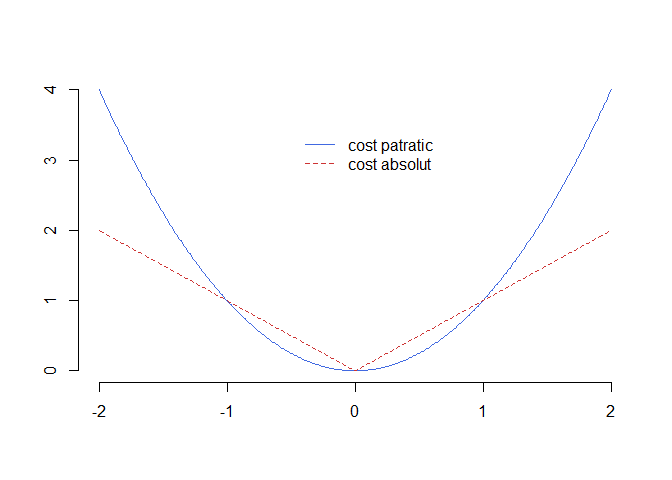

În acest curs vom studia modelul clasic de regresie liniară în care componenta sistematică $f$ face parte din clasa de funcții liniare $\mathcal{F} = \{f\,|\, f(x_1,\ldots,x_k) = \beta_0 + \beta_1 x_1 +\cdots+\beta_k x_k\}$, prin urmare media (condiționată) a lui $y$ este o combinație liniară de covariabile iar variabila răspuns este continuă:

$$y = \beta_0 + \beta_1 x_1 +\cdots+\beta_k x_k + \varepsilon.$$

Atunci când înlocuim cu observațiile obținem $n$ ecuații

$$y_i = \beta_0 + \beta_1 x_{i1} +\cdots+\beta_k x_{ik} + \varepsilon_i, \quad i = 1,\ldots,n,$$

cu parametrii necunoscuți (sau coeficienții de regresie) $\beta_0,\ldots,\beta_k$.

# 2 Seturi de date

În secțiunile care urmează vom prezenta o serie de seturi de date care vor fi utilizate pe parcursul acestor note pentru a ilustra noțiunile descrise.

## 2.1 Înălțimea arborilor de eucalipt

Scopul este de a găsi o relație între înălțimea arborilor și circumferința acestora în vederea estimării volumului de lemn din zona studiată (volum calculat după o formulă de tip trunchi de con). Reprezentarea setului de date este dat în figura de mai jos:

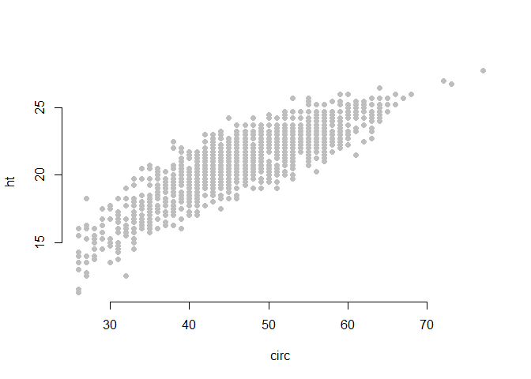

## 2.2 Prețul chiriei locuințelor în Munchen

Setul de date `Munchen` (care poate fi descărcat de aici) face referire la prețul net și respectiv prețul net pe metrul pătrat al chiriei unei locuințe din orașul Munchen, Germania pentru anul 1999. Setul de date prezintă prețurile a mai multe de 3000 de apartamente împreună cu o serie de variabile explicative precum suprafața de locuit, anul de construcție a imobilului, etc. Aceste informații pot fi găsite în tabelul de mai jos:

| Variabila | Descriere | Media/Frecvența | Abaterea standard | Min/Max |
| --- | --- | --- | --- | --- |
| `rent` | Prețul lunar net al chiriei (în Euro) | 459.44 | 195.66 | 40.51/1843.38 |
| `rentsqm` | Prețul lunar net al chiriei pe $m^2$ (în Euro) | 7.11 | 2.44 | 0.41/17.72 |
| `area` | Suprafața de locuit în $m^2$ | 67.37 | 23.72 | 20/160 |
| `yearc` | Anul de construcție | 1956 | 22.31 | 1918/1997 |
| `location` | Calitatea locației: 1 - medie, 2- bună și 3- de top | 58.91%, 39.26%, 2.53% |  |  |
| `bath` | Calitatea băilor: 0 - standard, 1 - premium | 93.8%, 6.2% |  |  |
| `kitchen` | Calitatea bucătariei: 0 - standard, 1 - premium | 95.75%, 4.25% |  |  |
| `cheating` | Încălzire centralizată: 0 - fără încălzire, 1 - cu încălzire | 10.42%, 89.58% |  |  |

## 2.3 Primii pași

Înainte de a începe analiza de regresie (sau orice altă analiză) este bine să înțelegem mai bine variabilele din setul de date cu care lucrăm. Pentru a realiza acest lucru, un prim pas constă în sumarizarea variabilelor atât prin statistici descriptive (calcularea mediilor, medianelor, a abaterilor standard, a valorilor minime și maxime, etc.) cât și prin tehnici de vizualizare (histograme, diagrame cu bare, boxplot, etc.). Atunci când lucrăm cu variabile cantitative, statisticile descriptive se rezumă la măsuri de locție (media, mediana, modul) și variație (abaterea standard, minimul, maximul) iar în cazul variabilelor calitative putem include frecvența de apariție a fiecărei categorie.

Dacă facem referire la setul de date a indicilor prețului chiriei în Munchen, atunci observăm că prețul net lunar variază între 40 și 1843 de Euro având o medie de 459 de Euro. Figura de mai jos arată cum este repartizat prețul net lunar și respectiv prețul net lunar pe $m^2$ și constatăm că pentru majoritatea apartamentelor acesta variază între 50 și 1200 de Euro:

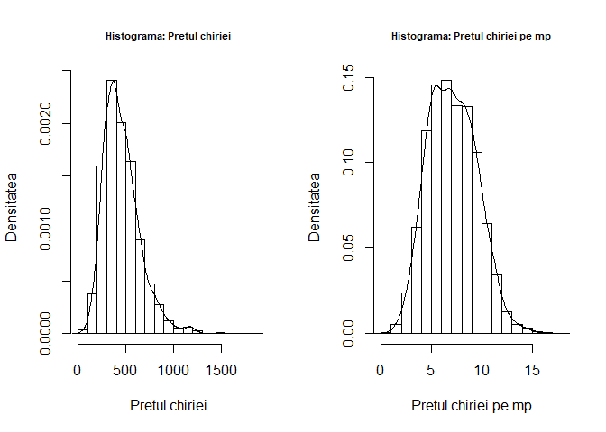

Ilustrați prin intermediul unei histograme (`hist()`) cum este repartizată suprafața de locuit (variabila `area`) și respectiv anul de construție a imobilului (variabila `yearc`).

În cazul în care ne interesăm asupra relației dintre variabila răspuns și variabila explicativă putem folsi ca metodă grafică diagrama de împrăștiere (scatterplot) în situația în care covariabila este continuă sau boxplot-ul în situația în care covariabila este categorică.

De exemplu, figura de mai jos prezintă diagrama de împrăștiere dintre prețul lunar net sau prețul lunar net pe $m^2$ și suprafața de locuit. Dat fiind numărul mare de observații graficul este aglomerat și nu foarte informativ. Cu toate acestea constatăm o oarecare relație liniară între prețul lunar net și suprafața de locuit precum și că variabilitatea prețului crește odată cu suprafața.

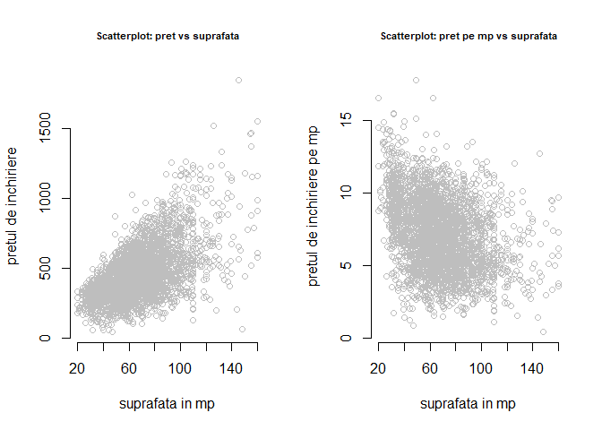

Atunci când variabila explicativă este categorială este de preferat utilizarea boxplot-ului (diagramei cu mustăți). Astfel, în figura următoare se poate observa că valoarea mediană a prețului lunar net al chiriei crește odată cu calitatea locației apartamentului.

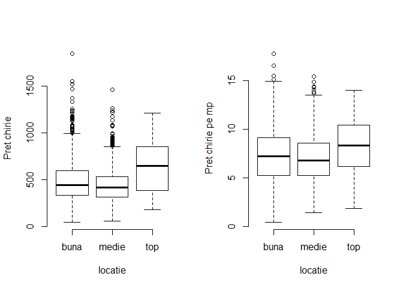

Ilustrați prin intermediul unei diagrame de împrăștiere relația dintre prețul lunar net sau prețul lunar net pe $m^2$ și anul de construcție a imobilului iar prin intermediul unui boxplot relația dintre prețul lunar net sau prețul lunar net pe $m^2$ și calitatea băii sau a bucătăriei.

Numărul mare de observații din setul de date face dificilă interpretarea diagramei de împrăștiere și în această situație o reprezentare grafică pe grupuri (clustere) de date este de preferat. De exemplu dacă numărul valorilor unice ale variabilei explicative este mic în raport cu numărul observațiilor atunci o idee ar fi să sumarizăm varaiabila răspuns pentru fiecare nivel (medie, medie - abatere standard, medie + abatere standard) și să ilustrăm doar datele sumarizate.

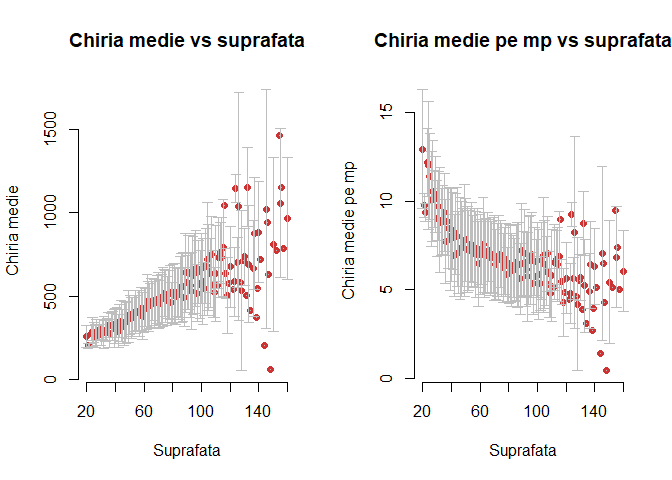

Funcția care permite trasarea graficului anterior este:

```r
plot.with.errorbars = function(x, y, err_low, err_up, ...) {

  ylim = c(min(err_low), max(err_up))

  plot(x, y, ylim=ylim,
       pch=16,
       bty = "n",
       col = "brown3",
       ...)
  arrows(x, err_low, x, err_up, length=0.05, angle=90, code=3,
         col = "grey")
}
```

# 3 Modelul de Regresie liniară simplă

În cele ce urmează vom considera cazul modelului de regresie liniară simplă

$$y = \beta_0 + \beta_1 x + \varepsilon,$$

unde, în forma generală $y = f(x) + \varepsilon$, media condiționată (componenta sistematică) $\mathbb{E}[y|x] = f(x)$ este presupusă liniară. Specific, pentru un eșantion de $n$ puncte $(x_i, y_i)$ modelul de regresie liniară simplă se scrie sub forma

$$y_i = \beta_0 + \beta_1 x_{i} + \varepsilon_i, \quad i = 1,\ldots,n.$$

Modelul clasic de regresie presupune că termenii eroare sunt variabile aleatoare necorelate, centrate și de varianță constantă (homoscedasticitate), altfel spus aceștia îndeplinesc ipotezele:

$$(\mathcal{H})\left\{\begin{array}{l}
\left(\mathcal{H}_{1}\right): \mathbb{E}\left[\varepsilon_{i}\right]=0 \text { pentru toți indicii } i \\
\left(\mathcal{H}_{2}\right): \operatorname{Cov}\left(\varepsilon_{i}, \varepsilon_{j}\right)=\delta_{i j} \sigma^{2} \text { pentru toate perechile }(i, j)
\end{array}\right.$$

unde $\delta_{ij} = 1$ dacă $i = j$ și $\delta_{ij} = 0$ altfel.

Pentru a determina coeficienții de regresie ($\beta_0$ și $\beta_1$) vom folosi ca funcție de pierdere, costul pătratic $L(u) = u^2$. În acest context, numim estimatori obținuți prin *metoda celor mai mici pătrate* (OLS - Ordinary Least Squares) valorile $\hat{\beta}_0$ și $\hat{\beta}_1$ care minimizează funcția ($RSS$ - Residual Sum of Squares)

$$RSS(\beta_0, \beta_1) = \sum_{i = 1}^{n}(y_i - \beta_0 - \beta_1 x_i)^2$$

altfel spus, dreapta de regresie obținută prin metoda celor mai mici pătrate minimizează distanțele verticale dintre punctele $(x_i,y_i)$ și dreapta ajustată $y = \hat{\beta}_0 + \hat{\beta}_1 x$. Pentru unicitatea estimatorilor $\hat{\beta}_0$ și $\hat{\beta}_1$ vom presupune că setul de date conține cel puțin două puncte de abscise diferite, i.e. $x_i\neq x_j$.

1. *Exemplu - Înălțimea arborilor de eucalipt*

Ca prim exemplu, putem considera setul de date referitor la înălțimea și circumferința arborilor de eucalipt. Modelul de regresie liniară simplă prin care dorim să explicăm înălțimea (medie) a arborilor (variabila răspuns) în funcție de circumferința lor (variabila explicativă) este dat de

$$ht_i = \beta_0 + \beta_1 circ_i + \varepsilon_i, \quad i =1,\ldots, 1429.$$

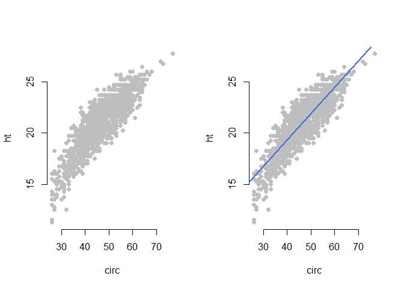

2. *Exemplu - Prețul chiriilor în Munchen*

Să considerăm acum setul de date referitor la prețul chiriilor în Munchen pentru apartamentele dintr-o locație medie, construite după anul 1966. Diagrama de împrăștiere ilustrată în figura de mai jos, prezintă o relație aproximativ liniară între prețul net al chiriei (variabila răspuns) și suprafață (covariabila).

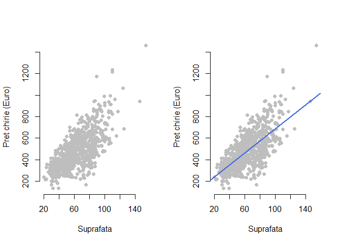

Modelul de regresie liniară simplă se scrie

$$pret_i = \beta_0 + \beta_1 suprafata_i + \varepsilon_i$$

ceea ce înseamnă că prețul de închiriere mediu este o funcție liniară de suprafața de locuit, i.e. $\mathbb{E}[pret|suprafata] = \beta_0 + \beta_1 suprafata$.

## 3.1 Metoda celor mai mici pătrate

### 3.1.1 Calculul estimatorilor prin metoda celor mai mici pătrate

Metoda celor mai mici pătrate este o metodă deterministă de calcul a estimatorilor coeficienților dreptei de regresie, ipotezele făcute asupra termenilor eroare nu intervin în acest calcul. Acestea din urmă vor interveni atunci când vrem să explicităm proprietățile statistice ale acestor estimatori.

Estimatorii $\hat{\beta}_0$ și $\hat{\beta}_1$ obținuți prin metoda celor mai mici pătrate, adică valorile coeficienților $\beta_0$ și $\beta_1$ care minimizează funcția

$$RSS(\beta_0, \beta_1) = \sum_{i = 1}^{n}(y_i - \beta_0 - \beta_1 x_i)^2$$

sunt dați de expresiile

$$\hat\beta_0 = \bar y - \hat\beta_1 \bar x \quad \text{și} \quad \hat\beta_1 = \frac{\sum_{i = 1}^{n}(x_i - \bar x)(y_i - \bar y)}{\sum_{i = 1}^{n}(x_i - \bar x)^2}.$$

Trebuie să determinăm

$$(\hat{\beta}_0, \hat{\beta}_1) = \underset{(\beta_0,\beta_1)\in\mathbb{R}\times\mathbb{R}}{\arg\min} RSS(\beta_0, \beta_1)$$

și observând că funcția $RSS(\beta_0, \beta_1)$ este convexă ea admite un punct de minim. Acesta se obține ca soluție a sistemului $\nabla RSS = 0$ de ecuații normale,

$$\left\{\begin{array}{ll}
\frac{\partial RSS}{\partial \beta_0} = -2\sum_{i = 1}^{n}(y_i - \beta_0 - \beta_1 x_i) = 0\\
\frac{\partial RSS}{\partial \beta_1} = -2\sum_{i = 1}^{n}x_i(y_i - \beta_0 - \beta_1 x_i) = 0
\end{array}\right.$$

Din prima ecuație obținem prin sumare $n\beta_0 + \beta_1\sum_{i=1}^{n}x_i = \sum_{i=1}^{n}y_i$ ceea ce conduce la $\hat\beta_0 = \bar y - \hat\beta_1 \bar x$.

A doua ecuație conduce la

$$\beta_0\sum_{i=1}^{n}x_i + \beta_1\sum_{i=1}^{n}x_i^2 = \sum_{i=1}^{n}x_iy_i$$

și înlocuind $\beta_0$ cu expresia obținută anterior, obținem soluția

$$\hat\beta_1 = \frac{\sum_{i = 1}^{n}x_i(y_i - \bar y)}{\sum_{i = 1}^{n}x_i(x_i - \bar x)} = \frac{\sum_{i = 1}^{n}(x_i - \bar x)(y_i - \bar y)}{\sum_{i = 1}^{n}(x_i - \bar x)^2} = \frac{\sum_{i = 1}^{n}(x_i - \bar x)y_i}{\sum_{i = 1}^{n}(x_i - \bar x)^2}.$$

De asemenea, se poate verifica că $RSS(\beta_0, \beta_1)$ se scrie sub forma

$$\begin{align*}
RSS(\beta_0, \beta_1) &= n\left[\beta_0 - (\bar y - \beta_1\bar x)\right]^2 + \left[\sum_{i = 1}^{n}(x_i - \bar x)^2\right]\left[\beta_1 - \frac{\sum_{i = 1}^{n}(x_i - \bar x)(y_i - \bar y)}{\sum_{i = 1}^{n}(x_i - \bar x)^2}\right]^2 \\
&\quad + \left[\sum_{i = 1}^{n}(y_i - \bar y)^2\right]\left[1 - \frac{\left(\sum_{i = 1}^{n}(x_i - \bar x)(y_i - \bar y)\right)^2}{\sum_{i = 1}^{n}(x_i - \bar x)^2\sum_{i = 1}^{n}(y_i - \bar y)^2}\right]
\end{align*}$$

care justifică în egală măsură soluția obținută anterior. $\square$

Odată ce am determinat estimatorii$\hat{\beta}_0$ și $\hat{\beta}_1$ putem scrie dreapta de regresie sub forma

$$\hat y = \hat \beta_0 + \hat\beta_1 x,$$

și, în acest context, dacă evaluăm dreapta în punctele $x_i$ care au ajutat la estimarea parametrilor atunci obținem valorile ajustate (fitate) $\hat y_i$ iar dacă evaluăm dreapta în alte puncte, valorile obținute se numesc valori prezise (valori previzionale). De asemenea, din $\hat\beta_0 = \bar y - \hat\beta_1 \bar x$ se remarcă faptul că dreapta de regresie trece prin punctul de coordonate $(\bar x, \bar y)$, centrul de greutate al norului de puncte.

> *Exemplu: prețul chiriilor în Munchen*

Putem ilustra modelul de regresie liniară simplă în contextul prețului chiriilor din Munchen pentru apartamentele construite după anul 1966 care se regăsesc într-o locție medie. Conform metodei celor mai mici pătrate, găsim că $\hat{\beta}_0=$ 130.554 și respectiv $\hat{\beta}_1=$ 5.576 ceea ce conduce la modelul

$$pret_i = 130.554 + 5.576 suprafata_i + \varepsilon_i.$$

Panta dreptei de regresie, coeficientul $\hat{\beta}_1=$ 5.576 poate fi interpretat în modul următor: dacă suprafața de locuit crește cu $1$ $m^2$ atunci prețul chiriei crește în medie cu 5.576 Euro.

### 3.1.2 Proprietăți ale estimatorilor obținuți prin metoda celor mai mici pătrate

Sub ipotezele făcute asupra termenilor eroare ($\mathcal{H}_1$ și $\mathcal{H}_2$), de centrare, necorelare și homoscedasticitate putem prezenta o serie de proprietăți ale estimatorilor obținuți prin metoda celor mai mici pătrate.

Estimatorii obținuți prin metoda celor mai mici pătrate, $\hat\beta_0$ și $\hat\beta_1$, sunt estimatori nedeplasați.

Coeficienții $\hat\beta_0$ și $\hat\beta_1$ obținuți prin metoda celor mai mici pătrate sunt dați de $\hat\beta_0 = \bar y - \hat\beta_1 \bar x$ și $\hat\beta_1 = \frac{\sum_{i = 1}^{n}(x_i - \bar x)(y_i - \bar y)}{\sum_{i = 1}^{n}(x_i - \bar x)^2}$ (aceștia sunt variabile aleatoare deoarece sunt funcții de $Y_i$ care sunt variabile aleatoare). Înlocuind în expresia lui $\hat\beta_1$ pe $y_i$ cu $\beta_0+\beta_1 x_i + \varepsilon_i$ avem

$$\begin{align*}
\hat\beta_1 &= \frac{\sum_{i = 1}^{n}(x_i - \bar x)(y_i - \bar y)}{\sum_{i = 1}^{n}(x_i - \bar x)^2} = \frac{\sum_{i = 1}^{n}(x_i - \bar x)y_i}{\sum_{i = 1}^{n}(x_i - \bar x)^2} = \frac{\sum_{i = 1}^{n}(x_i - \bar x)(\beta_0+\beta_1 x_i + \varepsilon_i)}{\sum_{i = 1}^{n}(x_i - \bar x)^2}\\
&= \frac{\beta_0\overbrace{\sum_{i = 1}^{n}(x_i - \bar x)}^{ = 0} + \beta_1 \sum_{i = 1}^{n}(x_i - \bar x)x_i + \sum_{i = 1}^{n}(x_i - \bar x)\varepsilon_i}{\sum_{i = 1}^{n}(x_i - \bar x)^2} = \frac{\beta_1 \sum_{i = 1}^{n}(x_i - \bar x)^2 + \sum_{i = 1}^{n}(x_i - \bar x)\varepsilon_i}{\sum_{i = 1}^{n}(x_i - \bar x)^2}\\
&= \beta_1 + \frac{\sum_{i = 1}^{n}(x_i - \bar x)\varepsilon_i}{\sum_{i = 1}^{n}(x_i - \bar x)^2}.
\end{align*}$$

Conform ipotezei modelului de regresie liniară simplă, $\mathbb{E}[\varepsilon_i] = 0$, prin urmare $\mathbb{E}[\hat\beta_1] = \beta_1$ ceea ce arată că $\hat\beta_1$ este un estimator nedeplasat pentru $\beta_1$.

În mod similar,

$$\mathbb{E}[\hat\beta_0] = \mathbb{E}[\bar y] - \bar x\mathbb{E}[\hat\beta_1] = \beta_0 + \bar x\beta_1 - \bar x\beta_1 = \beta_0$$

ceea ce arată că $\hat\beta_0$ este un estimator nedeplasat pentru $\beta_0$. $\square$

Putem de asemenea să determinăm varianța și covarianța estimatorilor $\hat\beta_0$ și $\hat\beta_1$.

Calculați matricea de varianță-covarianță a estimatorilor $\hat\beta_0$ și $\hat\beta_1$.

Notăm cu $W = \begin{pmatrix}Var(\hat \beta_0) & Cov(\hat \beta_0, \hat \beta_1)\\ Cov(\hat \beta_0, \hat \beta_1) & Var(\hat \beta_1)\end{pmatrix}$ matricea de varianță-covarianță a estimatorilor $\hat\beta_0$ și $\hat\beta_1$.

Avem, folosind expresia lui $\hat\beta_1$ determinată la punctul anterior și homoscedasticitatea și necorelarea erorilor $Cov(\varepsilon_i, \varepsilon_j) = \delta_{ij}\sigma^2$, că

$$\begin{align*}
Var(\hat \beta_1) &= Var\left(\beta_1 + \frac{\sum_{i = 1}^{n}(x_i - \bar x)\varepsilon_i}{\sum_{i = 1}^{n}(x_i - \bar x)^2}\right) = Var\left(\frac{\sum_{i = 1}^{n}(x_i - \bar x)\varepsilon_i}{\sum_{i = 1}^{n}(x_i - \bar x)^2}\right)\\
&= \frac{Var\left(\sum_{i = 1}^{n}(x_i - \bar x)\varepsilon_i\right)}{\left[\sum_{i = 1}^{n}(x_i - \bar x)^2\right]^2} = \frac{\sum_{i,j}(x_i - \bar x)(x_j - \bar x)Cov(\varepsilon_i, \varepsilon_j)}{\left[\sum_{i = 1}^{n}(x_i - \bar x)^2\right]^2}\\
&= \frac{\sum_{i = 1}^{n}(x_i - \bar x)^2\sigma^2}{\left[\sum_{i = 1}^{n}(x_i - \bar x)^2\right]^2} = \frac{\sigma^2}{\sum_{i = 1}^{n}(x_i - \bar x)^2}.
\end{align*}$$

Pentru a determina $Var(\hat \beta_0)$, vom folosi relația $\hat \beta_0 = \bar y - \hat \beta_1 \bar x$ ceea ce conduce la

$$\begin{align*}
Var(\hat \beta_0) &= Var(\bar y - \hat \beta_1 \bar x) = Var(\bar y) - 2Cov(\bar y, \hat \beta_1 \bar x) + Var(\hat \beta_1 \bar x)\\
&= Var\left(\frac{1}{n}\sum_{i = 1}^{n}y_i\right) - 2\bar x Cov(\bar y, \hat \beta_1) + \bar x^2 Var(\hat \beta_1)\\
&= \frac{\sigma^2}{n} + \bar x^2 \frac{\sigma^2}{\sum_{i = 1}^{n}(x_i - \bar x)^2} - 2\bar x Cov(\bar y, \hat \beta_1).
\end{align*}$$

Pentru $Cov(\bar y, \hat \beta_1)$ avem (ținând cont de faptul că $\beta_0$, $\beta_1$ și $x_i$ sunt constante)

$$\begin{align*}
Cov(\bar y, \hat \beta_1) &= Cov\left(\frac{1}{n}\sum_{i = 1}^{n}y_i, \beta_1 + \frac{\sum_{j = 1}^{n}(x_j - \bar x)\varepsilon_j}{\sum_{j = 1}^{n}(x_j - \bar x)^2} \right) = \frac{1}{n}\sum_{i = 1}^{n}Cov\left(\beta_0 + \beta_1 x_i + \varepsilon_i, \beta_1 + \frac{\sum_{j = 1}^{n}(x_j - \bar x)\varepsilon_j}{\sum_{j = 1}^{n}(x_j - \bar x)^2}\right)\\
&= \frac{1}{n}\sum_{i = 1}^{n}Cov\left(\varepsilon_i, \frac{\sum_{j = 1}^{n}(x_j - \bar x)\varepsilon_j}{\sum_{j = 1}^{n}(x_j - \bar x)^2}\right) = \frac{1}{n}\sum_{i = 1}^{n}\frac{1}{\sum_{j = 1}^{n}(x_j - \bar x)^2}Cov\left(\varepsilon_i, \sum_{j = 1}^{n}(x_j - \bar x)\varepsilon_j\right)\\
&= \frac{1}{\sum_{j = 1}^{n}(x_j - \bar x)^2}\sum_{i = 1}^{n}\frac{1}{n}\sum_{j = 1}^{n}(x_j - \bar x)Cov(\varepsilon_i, \varepsilon_i=j) = \frac{1}{\sum_{j = 1}^{n}(x_j - \bar x)^2}\sum_{i = 1}^{n}\frac{1}{n}\sum_{j = 1}^{n}(x_j - \bar x)\delta_{ij}\sigma^2\\
&= \frac{\sigma^2}{\sum_{j = 1}^{n}(x_j - \bar x)^2}\frac{1}{n}\underbrace{\sum_{i = 1}^{n}(x_i - \bar x)}_{=0} = 0
\end{align*}$$

prin urmare

$$Var(\hat \beta_0) = \frac{\sigma^2}{n} + \bar x^2 \frac{\sigma^2}{\sum_{i = 1}^{n}(x_i - \bar x)^2} = \frac{\sigma^2\sum_{i = 1}^{n}x_i^2}{n\sum_{i = 1}^{n}(x_i - \bar x)^2}.$$

Calculul covarianței dintre $\hat \beta_0$ și $\hat \beta_1$ rezultă aplicând relațiile de mai sus

$$Cov(\hat \beta_0, \hat \beta_1) = Cov(\bar y - \hat \beta_1\bar x, \hat \beta_1) = Cov(\bar y, \hat \beta_1) - \bar x Var(\hat \beta_1) = -\frac{\sigma^2 \bar x}{\sum_{i = 1}^{n}(x_i - \bar x)^2}.$$

Observăm că $Cov(\hat \beta_0, \hat \beta_1)\leq 0$ iar intuitiv, cum dreapta de regresie (bazată pe estimatorii obținuți prin metoda celor mai mici pătrate) $\bar y = \hat\beta_0 + \hat\beta_1 \bar x$ trece prin centrul de greutate al datelor $(\bar x, \bar y)$, dacă presupunem $\bar x > 0$ remarcăm că atunci când creștem panta (creștem $\hat\beta_1$) ordonata la origine scade (scade $\hat\beta_0$) și reciproc.

Matricea de varianță-covarianță a estimatorilor $\hat\beta_0$ și $\hat\beta_1$ devine

$$W = \begin{pmatrix}Var(\hat \beta_0) & Cov(\hat \beta_0, \hat \beta_1)\\ Cov(\hat \beta_0, \hat \beta_1) & Var(\hat \beta_1)\end{pmatrix} = \begin{pmatrix}\frac{\sigma^2\sum_{i = 1}^{n}x_i^2}{n\sum_{i = 1}^{n}(x_i - \bar x)^2} & -\frac{\sigma^2 \bar x}{\sum_{i = 1}^{n}(x_i - \bar x)^2}\\ -\frac{\sigma^2 \bar x}{\sum_{i = 1}^{n}(x_i - \bar x)^2} & \frac{\sigma^2}{\sum_{i = 1}^{n}(x_i - \bar x)^2}\end{pmatrix}. \square$$

Din expresia $Var(\hat \beta_1)$ observăm că dacă $\sigma^2$ este mică (cu alte cuvinte $y_i$ sunt aproape de dreapta de regresie) atunci estimarea este mai precisă. De asemenea, se constată că pe măsură ce valorile $x_i$ sunt mai dispersate în jurul valorii medii $\bar x$ estimarea coeficientului $\hat \beta_1$ este mai precisă ($Var(\hat \beta_1)$ este mai mică). Acest fenomen se poate observa și în figura de mai jos în care am generat $100$ de valori aleatoare $X$ și $100$ de valori pentru $Y$ după modelul

$$y = 1 + 2 x + \varepsilon$$
cu $\varepsilon\sim \mathcal{N}(0, \sigma^2)$. Dreapta roșie descrie adevărata relație $f(x) = 1 + 2x$ în populație iar dreapta albastră reprezintă dreapta de regresie calculată cu ajutorul metodei celor mai mici pătrate (OLS). Dreptele albastru deschis au fost generate tot cu ajutorul metodei celor mai mici pătrate atunci când variem $\sigma^2$ (în figura din stânga) și respectiv pe $x_i$ în jurul lui $\bar x$ (în figura din dreapta).

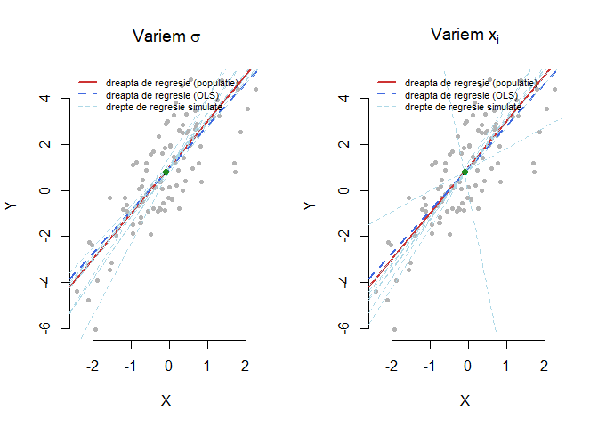

Rezultatul următor, cunoscut și sub numele de *Teorema Gauss-Markov*, afirmă că estimatorii obținuți prin metoda celor mai mici pătrate sunt optimali în clasa estimatorilor liniari și nedeplasați.

În clasa estimatorilor nedeplasați și liniari în $y$, estimatorii $\hat\beta_0$ și $\hat\beta_1$ sunt de varianță minimală.

Începrem prin a reaminti că un estimator este liniar în $y$ dacă se poate scrie sub forma $\sum_{i=1}^{n}d_i y_i$ cu $d_1,\ldots,d_n$ constante. Să observăm că atât $\hat\beta_0$ cât și $\hat\beta_1$ sunt estimatori liniari în $y_i$, $\hat\beta_1 = \sum_{i=1}^{n}\lambda_i y_i$ unde $\lambda_i = \frac{(x_i - \bar x)}{\sum_{i = 1}^{n}(x_i - \bar x)^2}$.

Fie $\tilde \beta_1$ un alt estimator liniar și nedeplasat pentru $\beta_1$, cu alte cuvinte

$$\underbrace{\tilde\beta_1 = \sum_{i=1}^{n}d_i y_i}_{liniaritate} \quad \text{și}\quad \underbrace{\mathbb{E}[\tilde\beta_1] = \beta_1,\, \forall\beta_0,\beta_1}_{nedeplasare}.$$

Observăm că

$$\mathbb{E}[\tilde\beta_1] = \beta_0\sum_{i = 1}^{n}d_i + \beta_1\sum_{i = 1}^{n}d_i x_i + \sum_{i = 1}^{n}d_i\underbrace{\mathbb{E}[\varepsilon_i]}_{=0} = \beta_0\sum_{i = 1}^{n}d_i + \beta_1\sum_{i = 1}^{n}d_i x_i$$

prin urmare, folosind proprietatea de nedeplasare, $\beta_0\sum_{i = 1}^{n}d_i + \beta_1\sum_{i = 1}^{n}d_i x_i = \beta_1$ pentru orice valori ale lui $\beta_0$ și $\beta_1$ ceea ce implică $\sum_{i = 1}^{n}d_i = 0$ și respectiv $\sum_{i = 1}^{n}d_i x_i = 1$.

Pentru a verifica inegalitatea $Var(\tilde\beta_1)\geq Var(\hat\beta_1)$, să notăm că

$$Var(\tilde\beta_1) = Var(\tilde\beta_1 - \hat\beta_1) + Var(\hat\beta_1) + 2Cov(\tilde\beta_1 - \hat\beta_1, \hat\beta_1)$$

dar

$$Cov(\tilde\beta_1 - \hat\beta_1, \hat\beta_1) = Cov(\tilde\beta_1, \hat\beta_1) - Var(\hat\beta_1) = \sigma^2\frac{\sum_{i = 1}^{n}d_i(x_i - \bar x)}{\sum_{i = 1}^{n}(x_i - \bar x)^2} - \frac{\sigma^2}{\sum_{i = 1}^{n}(x_i - \bar x)^2}$$

și ținând cont că $\sum_{i = 1}^{n}d_i = 0$ și $\sum_{i = 1}^{n}d_i x_i = 1$ rezultă că $Cov(\tilde\beta_1 - \hat\beta_1, \hat\beta_1) = 0$ ceea ce conduce la

$$Var(\tilde\beta_1) = Var(\tilde\beta_1 - \hat\beta_1) + Var(\hat\beta_1) \geq Var(\hat\beta_1) \quad\square$$

### 3.1.3 Valori reziduale

În modelul de regresie liniară simplă am estimat prin intermediul metodei celor mai mici pătrate atât ordonata la origine a dreptei de regresie, coeficientul $\hat\beta_0$, cât și panta acesteia, coeficientul $\hat\beta_1$. Definim *valorile reziduale* $\hat\varepsilon_i$ ca fiind diferența dintre ordonata observată a punctului și ordonata ajustată la dreapta de regresie, altfel spus

$$\hat{\varepsilon}_{i}=y_{i}-\hat{y}_{i}=y_{i}-\hat{\beta}_{0}-\hat{\beta}_{1} x_{i}.$$

În cadrul modelului de regresie liniară simplă, suma valorilor reziduale este nulă.

Observăm, folosind definiția $\hat\varepsilon_i = y_i - \hat y_i$, că

$$\begin{align*}
\sum_{i = 1}^{n}\hat\varepsilon_i &= \sum_{i = 1}^{n}(y_i - \hat y_i) = \sum_{i = 1}^{n}(y_i - \hat \beta_0 - x_i\hat\beta_1)\\
&= \sum_{i = 1}^{n}\left[y_i - \underbrace{(\bar y - \bar x\hat\beta_1)}_{= \hat \beta_0} - x_i\hat\beta_1\right] = \sum_{i = 1}^{n}(y_i - \bar y) -\hat\beta_1 \sum_{i = 1}^{n}(x_i - \bar x) = 0. \quad\square
\end{align*}$$

Trebuie observat că atât varianțele cât și covarianța estimatorilor $\hat\beta_0$ și $\hat\beta_1$ depind de varianța termenului eroare $\sigma^2$, care în general nu este cunoscută. În propoziția de mai jos este propus un estimator nedeplasat a lui $\sigma^2$.

În modelul de regresie liniară simplă statistica $\hat\sigma^2 = \frac{1}{n-2}\sum_{i = 1}^{n}\hat\varepsilon_i^2$ este un estimator nedeplasat pentru $\sigma^2$.

Ținând cont de faptul că $\hat\beta_0 = \bar y - \hat\beta_1 \bar x$ și $\bar y = \beta_0 + \beta_1 \bar x + \bar \varepsilon$ (prin însumarea după $i$ a relațiilor $y_i = \beta_0 + \beta_1 x_i +\varepsilon_i$) găsim că

$$\begin{align*}
\hat\varepsilon_i &= y_i - \hat y_i = (\beta_0 + \beta_1 x_i +\varepsilon_i) - (\hat\beta_0 + \hat\beta_1 x_i) \\
&= (\underbrace{\bar y - \beta_1 \bar x - \bar \varepsilon}_{=\beta_0} + \beta_1 x_i +\varepsilon_i) - (\bar y - \hat\beta_1 \bar x + \hat\beta_1 x_i)\\
&= (\beta_1 - \hat\beta_1)(x_i - \bar x) + (\varepsilon_i - \bar\varepsilon)
\end{align*}$$

și prin dezvoltarea binomului și utilizând relația $\hat\beta_1 = \beta_1 + \frac{\sum_{i = 1}^{n}(x_i - \bar x)\varepsilon_i}{\sum_{i = 1}^{n}(x_i - \bar x)^2}$ găsim

$$\begin{align*}
\sum_{i = 1}^{n}\hat\varepsilon_i^2 &= (\beta_1 - \hat\beta_1)^2\sum_{i = 1}^{n}(x_i - \bar x) + \sum_{i = 1}^{n}(\varepsilon_i - \bar\varepsilon)^2 + 2(\beta_1 - \hat\beta_1)\sum_{i = 1}^{n}(x_i - \bar x)(\varepsilon_i - \bar\varepsilon)\\
&= (\beta_1 - \hat\beta_1)^2\sum_{i = 1}^{n}(x_i - \bar x) + \sum_{i = 1}^{n}(\varepsilon_i - \bar\varepsilon)^2 + 2(\beta_1 - \hat\beta_1)\sum_{i = 1}^{n}(x_i - \bar x)\varepsilon_i - 2(\beta_1 - \hat\beta_1)\bar\varepsilon\sum_{i = 1}^{n}(x_i - \bar x)\\
&= (\beta_1 - \hat\beta_1)^2\sum_{i = 1}^{n}(x_i - \bar x) + \sum_{i = 1}^{n}(\varepsilon_i - \bar\varepsilon)^2 - 2(\beta_1 - \hat\beta_1)^2\sum_{i = 1}^{n}(x_i - \bar x)^2\\
&=\sum_{i = 1}^{n}(\varepsilon_i - \bar\varepsilon)^2 - (\beta_1 - \hat\beta_1)^2\sum_{i = 1}^{n}(x_i - \bar x)^2.
\end{align*}$$

unde am folosit că $\mathbb{E}\left(\frac{1}{n-1}\sum_{i = 1}^{n}(\varepsilon_i - \bar\varepsilon)^2\right) = \sigma^2$ (deoarece $Var(\varepsilon_i) = \sigma^2$).

Concluzionăm că $\hat\sigma^2 = \frac{1}{n-2}\sum_{i = 1}^{n}\hat\varepsilon_i^2$ este un estimator nedeplasat pentru $\sigma^2$. $\square$

> *Exemplu: prețul chiriilor în Munchen*

$$W = \begin{pmatrix}Var(\hat \beta_0) & Cov(\hat \beta_0, \hat \beta_1)\\ Cov(\hat \beta_0, \hat \beta_1) & Var(\hat \beta_1)\end{pmatrix} = \begin{pmatrix}\frac{\sigma^2\sum_{i = 1}^{n}x_i^2}{n\sum_{i = 1}^{n}(x_i - \bar x)^2} & -\frac{\sigma^2 \bar x}{\sum_{i = 1}^{n}(x_i - \bar x)^2}\\ -\frac{\sigma^2 \bar x}{\sum_{i = 1}^{n}(x_i - \bar x)^2} & \frac{\sigma^2}{\sum_{i = 1}^{n}(x_i - \bar x)^2}\end{pmatrix} = \begin{pmatrix}208.29 & -2.96\\ -2.96 & 0.04\end{pmatrix}.$$

### 3.1.4 Predicție

Unul dintre scopurile modelului de regresie este acela de a face predicție, cu alte cuvinte de a prezice valoarea variabilei răspuns $y$ în raport cu o nouă observație a variabilei explicative $x$.

Fie $x_{n+1}$ o nouă valoare pentru variabila explicativă și ne propunem să prezicem valoarea $y_{n+1}$ conform modelului

$$y_{n+1} = \beta_0 + \beta_1 x_{n+1} + \varepsilon_{n+1}$$

cu $\mathbb{E}[\varepsilon_{n+1}] = 0$, $Var(\varepsilon_{n+1}) = \sigma^2$ și $Cov(\varepsilon_{n+1}, \varepsilon_i)=0$ pentru $i = 1,\ldots,n$.

Atunci varianța răspunsului mediu prezis este

$$Var(\hat y_{n+1}) = \sigma^2\left[\frac{1}{n} + \frac{(x_{n+1} - \bar x)^2}{\sum_{i=1}^{n}(x_i - \bar x)^2}\right]$$

iar varianța erorii de predicție $\hat\varepsilon_{n+1}$ satisface $\mathbb{E}[\hat\varepsilon_{n+1}] = 0$ și

$$Var(\hat\varepsilon_{n+1}) = \sigma^2\left[1 + \frac{1}{n} + \frac{(x_{n+1} - \bar x)^2}{\sum_{i=1}^{n}(x_i - \bar x)^2}\right].$$

Cum $\hat y_{n+1} = \hat\beta_0 + \hat\beta_1 x_{n+1}$ avem

$$\begin{align*}
Var(\hat y_{n+1}) &= Var(\hat\beta_0 + \hat\beta_1 x_{n+1}) = Var(\hat\beta_0) + 2Cov(\hat\beta_0, \hat\beta_1) + x_{n+1}^2Var(\hat\beta_1)\\
&= \frac{\sigma^2\sum_{i = 1}^{n}x_i^2}{n\sum_{i = 1}^{n}(x_i - \bar x)^2} - 2\frac{\sigma^2 \bar x}{\sum_{i = 1}^{n}(x_i - \bar x)^2} + \frac{\sigma^2x_{n+1}^2}{\sum_{i = 1}^{n}(x_i - \bar x)^2}\\
&= \frac{\sigma^2}{\sum_{i = 1}^{n}(x_i - \bar x)^2}\left[\frac{1}{n}\sum_{i = 1}^{n}x_i^2 - 2x_{n+1}\bar x + x_{n+1}^2\right]\\
&= \frac{\sigma^2}{\sum_{i = 1}^{n}(x_i - \bar x)^2}\left[\frac{1}{n}\sum_{i = 1}^{n}(x_i -\bar x)^2 + \bar x^2 - 2x_{n+1}\bar x + x_{n+1}^2\right]\\
&= \sigma^2\left[\frac{1}{n} + \frac{(x_{n+1} - \bar x)^2}{\sum_{i=1}^{n}(x_i - \bar x)^2}\right].
\end{align*}$$

Constatăm că atunci când $x_{n+1}$ este departe de valoarea medie $\bar x$ răspunsul mediu are o variabilitate mai mare.

Pentru a obține varianța erorii de predicție $\hat\varepsilon_{n+1} = y_{n+1} - \hat y_{n+1}$ să observăm că $y_{n+1}$ depinde doar de $\varepsilon_{n+1}$ pe când $\hat y_{n+1}$ depinde de $\varepsilon_i$, $i\in\{1,2,\ldots,n\}$. Din necorelarea erorilor deducem că

$$Var(\hat\varepsilon_{n+1}) = Var(y_{n+1} - \hat y_{n+1}) = Var(y_{n+1}) + Var(\hat y_{n+1}) = \sigma^2\left[1 + \frac{1}{n} + \frac{(x_{n+1} - \bar x)^2}{\sum_{i=1}^{n}(x_i - \bar x)^2}\right].$$

## 3.2 Coeficientul de determinare $R^2$ și coeficientul de corelație

În această secțiune încercăm să abordăm problema de regresie liniară simplă într-un context geometric. Din punct de vedere vectorial dispunem de doi vectori: vectorul $X = (x_1, x_2, \ldots, x_n)^\intercal$ a celor $n$ observații ale variabilei explicative și vectorul $Y = (y_1, y_2, \ldots, y_n)^\intercal$ compus din cele $n$ observații ale variabilei răspuns, pe care vrem să o explicăm. Cei doi vectori aparțin spațiului $\mathbb{R}^n$.

Fie $\mathbf{1} = (1,1,\ldots,1)^\intercal\in\mathbb{R}^n$ și $\mathcal{M}(X)$ subspațiul liniar din $\mathbb{R}^n$ de dimensiune $2$ generat de vectorii $\{\mathbf{1}, X\}$ (acești vectori nu sunt coliniari deoarece $X$ conține cel puțin două elemente distincte). Notăm cu $\hat Y$ proiecția ortogonală a lui $Y$ pe subspațiul $\mathcal{M}(X)$ și cum $\{\mathbf{1}, X\}$ formează o bază în $\mathcal{M}(X)$ deducem că există $\hat\beta_0, \hat\beta_1\in \mathbb{R}$ astfel ca $\hat Y = \hat\beta_0\mathbf{1} + \hat\beta_1 X$. Cum, din definiția priecției ortogonale, $\hat Y$ este unicul vector din $\mathcal{M}(X)$ care minimizează distanța euclidiană (deci și pătratul ei)

$$\left\lVert Y - \hat Y \right\rVert^2 = \sum_{i = 1}^{n}[y_i - (\hat\beta_0 + \hat \beta_1 x_i)]^2$$

deducem că $\hat\beta_0, \hat\beta_1$ coincid cu valorile obținute prin metoda celor mai mici pătrate. Astfel coeficienții $\hat\beta_0$ și $\hat\beta_1$ se reprezintă coordonatele proiecției ortogonale a lui $Y$ pe subspațiul generat de vectorii $\{\mathbf{1}, X\}$ (a se vedea figura de mai jos).

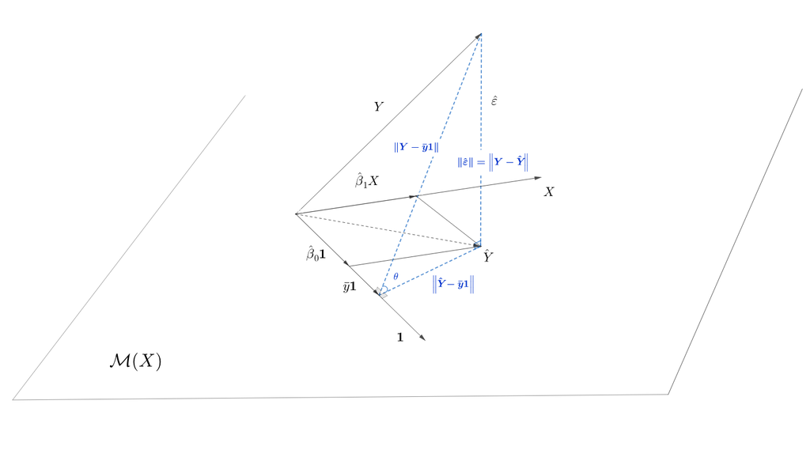

Observăm că, în general, vectorii $\{\mathbf{1}, X\}$ nu formează o bază ortogonală în $\mathcal{M}(X)$ (cu excepția cazului în care $\langle \mathbf{1}, X\rangle = n\bar x = 0$) prin urmare $\hat\beta_0\mathbf{1}$ nu este proiecția ortogonală a lui $Y$ pe $\mathbf{1}$ (aceasta este $\frac{\langle Y, \mathbf{1}\rangle}{\lVert \mathbf{1}\rVert^2}\mathbf{1} = \bar y\mathbf{1}$) iar $\hat\beta_1 X$ nu este proiecția ortogonală a lui $Y$ pe $X$ (aceasta fiind $\frac{\langle Y, X\rangle}{\lVert X\rVert^2}X$).

Fie $\hat\varepsilon = Y - \hat Y = (\hat\varepsilon_1, \hat\varepsilon_2, \ldots, \hat\varepsilon_n)^\intercal$ vectorul valorilor reziduale. Aplicând Teorema lui Pitagora (în triunghiul albastru) rezultă (descompunerea ANOVA pentru regresie) că

$$\begin{align*}
\left\lVert Y - \bar y \mathbf{1}\right\rVert^2 &= \left\lVert \hat Y - \bar y \mathbf{1}\right\rVert^2 + \left\lVert \underbrace{\hat\varepsilon}_{Y - \hat Y}\right\rVert^2\\
\sum_{i = 1}^{n}(y_i - \bar y)^2 &= \sum_{i = 1}^{n}(\hat y_i - \bar y)^2 + \sum_{i = 1}^{n}(\underbrace{\hat\varepsilon_i}_{y_i - \hat y_i})^2\\
SS_T &= SS_{reg} + RSS
\end{align*}$$

unde $SS_T = \sum_{i = 1}^{n}(y_i - \bar y)^2$ reprezintă suma abaterilor pătratice totale (Total Sum of Squares), $SS_{reg} = \sum_{i = 1}^{n}(\hat y_i - \bar y)^2$ reprezintă suma abaterilor pătratice explicate de modelul de regresie (Regression Sum of Squares) iar $RSS = \sum_{i = 1}^{n}\hat\varepsilon_i^2$ reprezintă suma abaterilor pătratice reziduale (Residual Sum of Squares).

*Coeficientul de determinare* $R^2$ este definit prin

$$R^2 = \frac{SS_{reg}}{SS_T} = \frac{\left\lVert \hat Y - \bar y \mathbf{1}\right\rVert^2}{\left\lVert Y - \bar y \mathbf{1}\right\rVert^2} = 1 - \frac{\left\lVert \hat \varepsilon\right\rVert^2}{\left\lVert Y - \bar y \mathbf{1}\right\rVert^2}$$

și conform figurii de mai sus $R^2 = \cos^2(\theta)$. Prin urmare dacă $R^2 = 1$, atunci $\theta = 0$ și $Y\in\mathcal{M}(X)$, deci $y_i = \beta_0 + \beta_1 x_i$, $i\in\{1,2,\ldots,n\}$ (punctele eșantionului sunt perfect aliniate) iar dacă $R^2 = 0$, deducem că $\sum_{i = 1}^{n}(\hat y_i - \bar y)^2 = 0$, deci $\hat y_i = \bar y$ (modelul liniar nu este adaptat în acest caz, nu putem explica mai bine decât media).

În modelul de regresie liniară simplă avem

$$R^2 = r_{xy}^2 = r_{y\hat y}^2$$

unde $r_{xy}$ este coeficientul de corelație empiric dintre $x$ și $y$.

Din definiția coeficientului de determinare și folosind coeficienții $\hat\beta_0 = \bar y - \hat\beta_1 \bar x$ și $\hat\beta_1 = \frac{\sum_{i = 1}^{n}(x_i - \bar x)(y_i - \bar y)}{\sum_{i = 1}^{n}(x_i - \bar x)^2}$ obținuți prin metoda celor mai mici pătrate avem

$$\begin{align*}
R^2 &= \frac{\left\lVert \hat Y - \bar y \mathbf{1}\right\rVert^2}{\left\lVert Y - \bar y \mathbf{1}\right\rVert^2} = \frac{\sum_{i = 1}^{n}(\hat\beta_0 + \hat\beta_1 x_i - \bar y)^2}{\sum_{i = 1}^{n}(y_i - \bar y)^2} = \frac{\sum_{i = 1}^{n}(\bar y - \hat\beta_1 \bar x + \hat\beta_1 x_i - \bar y)^2}{\sum_{i = 1}^{n}(y_i - \bar y)^2}\\
&= \frac{\hat\beta_1^2\sum_{i = 1}^{n}(x_i - \bar x)^2}{\sum_{i = 1}^{n}(y_i - \bar y)^2} = \left(\frac{\sum_{i = 1}^{n}(x_i - \bar x)(y_i - \bar y)}{\sum_{i = 1}^{n}(x_i - \bar x)^2}\right)^2\frac{\sum_{i = 1}^{n}(x_i - \bar x)^2}{\sum_{i = 1}^{n}(y_i - \bar y)^2}\\
& = \frac{\left[\sum_{i = 1}^{n}(x_i - \bar x)(y_i - \bar y)\right]^2}{\sum_{i = 1}^{n}(x_i - \bar x)^2\sum_{i = 1}^{n}(y_i - \bar y)^2} = r_{xy}^2.
\end{align*}$$

Pentru a verifica a doua parte, $R^2 = r_{y\hat y}^2$, să observăm că

$$r_{y\hat y}^2 = \frac{\left[\sum_{i = 1}^{n}(\hat y_i - \bar{\hat y})(y_i - \bar y)\right]^2}{\sum_{i = 1}^{n}(\hat y_i - \bar{\hat y})^2\sum_{i = 1}^{n}(y_i - \bar y)^2}$$

iar $\bar{\hat y} = \frac{\sum_{i = 1}^{n}\hat y_i}{n} = \hat \beta_0 + \hat\beta_1 \bar x = \bar y$, prin urmare

$$r_{y\hat y}^2 = \frac{\left[\sum_{i = 1}^{n}(\hat y_i - \bar{y})(y_i - \bar y)\right]^2}{\sum_{i = 1}^{n}(\hat y_i - \bar{y})^2\sum_{i = 1}^{n}(y_i - \bar y)^2}.$$

De asemenea

$$\begin{align*}
\sum_{i = 1}^{n}(\hat y_i - \bar{y})(y_i - \bar y) &= \sum_{i = 1}^{n}(\hat y_i - \bar{y})(y_i - \hat y_i + \hat y_i - \bar y) \\
&= \sum_{i = 1}^{n}(\hat y_i - \bar{y})(y_i - \hat y_i) + \sum_{i = 1}^{n}(\hat y_i - \bar{y})^2
\end{align*}$$

și cum

$$\begin{align*}
\sum_{i = 1}^{n}(\hat y_i - \bar{y})(y_i - \hat y_i) &= \sum_{i = 1}^{n}(\hat \beta_0 + \hat\beta_1 x_i - \bar{y})(y_i - \hat \beta_0 - \hat\beta_1 x_i) \\
&= \sum_{i = 1}^{n}(\bar y - \hat\beta_1 \bar x + \hat\beta_1 x_i - \bar{y})[(y_i - \bar y ) - \hat\beta_1 (x_i - \bar x)]\\
&= \hat\beta_1 \sum_{i = 1}^{n}(x_i - \bar x)(y_i - \bar y) - \hat\beta_1^2 \sum_{i = 1}^{n}(x_i - \bar x)^2 \\
&= \underbrace{\frac{S_{xy}}{S_{xx}}}_{\hat\beta_1}S_{xy} - \frac{S_{xy}^2}{S_{xx}^2}S_{xx} = 0
\end{align*}$$

deducem că $r_{y\hat y}^2 = \frac{\sum_{i = 1}^{n}(\hat y_i - \bar{y})^2}{\sum_{i = 1}^{n}(y_i - \bar y)^2} = R^2$.

> *Exemplu: prețul chiriilor în Munchen*

Pentru a vedea dacă modelul de regresie liniară simplă este potrivit în contextul setului de date referitor la prețul chiriilor în Munchen, vom calcula coeficientul de determinare $R^2$. Astfel obținem că $R^2 =$ 0.472 ceea ce implică faptul că modelul nostru nu este foarte bine ajustat la date. Trebuie să ținem cont că modelul ales este unul simplu și de asemenea să remarcăm faptul că setul de date nu respectă întru totul ipoteza homoscedasticității erorilor, se observă că variabilitatea în prețul chiriilor crește odată cu creșterea suprafeței de locuit. Această problemă va fi tratată într-o secțiune ulterioară care face referire la validarea ipotezelor modelului propus.

## 3.3 Inferență statistică - cazul erorilor gaussiene

Până în acest moment am determinat valorile estimatorilor coeficienților dreptei de regresie și varianțele acestor estimatori dar nu am vorbit despre modul în care aceștia sunt repartizați. Pentru a putea face acest lucru trebuie să adăugăm o ipoteză nouă asupra termenilor eroare $\varepsilon_i$ ce face referire la modul de repartizare a acestora. Vom presupune că termenii eroare sunt normal repartizați și în acest caz ipotezele $\mathcal{H}_1$ și $\mathcal{H}_2$ se scriu sub forma

$$(\mathcal{H})\left\{\begin{array}{l}
\left(\mathcal{H}_{1}\right): \varepsilon_{i} \sim \mathcal{N}\left(0, \sigma^{2}\right) \\
\left(\mathcal{H}_{2}\right): \varepsilon_{i} \text { independente }
\end{array}\right.$$

Prin urmare modelul de regresie liniară simplă devine un model parametric guvernat de parametrul $\theta = (\beta_0, \beta_1, \sigma^2)$ care ia valori în $\theta\in\Theta = \mathbb{R}\times\mathbb{R}\times\mathbb{R}_+^*$. Cum cunoaștem repartițiile termenilor eroare putem determina și repartițiile variabilelor răspuns $y_i$,

$$\forall i \in\{1, \ldots, n\} \quad y_{i} \sim \mathcal{N}\left(\beta_{1}+\beta_{2} x_{i}, \sigma^{2}\right),$$

iar $y_i$ sunt independente pentru că $\varepsilon_i$ sunt. Astfel putem calcula funcția de verosimilitate și estimatorii de verosimilitate maximă pentru $\theta$. Funcția de verosimilitate se scrie

$$\begin{aligned}
L\left(\beta_{0}, \beta_{1}, \sigma^{2}\right) &=\left(\frac{1}{\sqrt{2 \pi \sigma^{2}}}\right)^{n} \exp \left[-\frac{1}{2 \sigma^{2}} \sum_{i=1}^{n}\left(y_{i}-\beta_{0}-\beta_{1} x_{i}\right)^{2}\right] \\
&=\left(\frac{1}{\sqrt{2 \pi \sigma^{2}}}\right)^{n} \exp \left[-\frac{1}{2 \sigma^{2}} RSS\left(\beta_{0}, \beta_{1}\right)\right]
\end{aligned}$$

iar logaritmul acesteia devine

$$\ell(\beta_{0}, \beta_{1}, \sigma^{2}) = \log L\left(\beta_{0}, \beta_{1}, \sigma^{2}\right) = -\frac{n}{2} \log \left(2 \pi \sigma^{2}\right)-\frac{1}{2 \sigma^{2}} RSS\left(\beta_{0}, \beta_{1}\right).$$

$$\frac{\partial \log L\left(\hat{\beta}_{0}, \hat{\beta}_{1}, \sigma^{2}\right)}{\partial \sigma^{2}}=-\frac{n}{2 \sigma^{2}}+\frac{1}{2 \sigma^{4}} RSS\left(\hat{\beta}_{0}, \hat{\beta}_{1}\right)=-\frac{n}{2 \sigma^{2}}+\frac{1}{2 \sigma^{4}} \sum_{i=1}^{n}\left(y_{i}-\hat{\beta}_{0}-\hat{\beta}_{1} x_{i}\right)^{2}$$

și rezolvând ecuașia $\frac{\partial \log L\left(\hat{\beta}_{0}, \hat{\beta}_{1}, \sigma^{2}\right)}{\partial \sigma^{2}}= 0$ găsim

$$\sigma^2_{MLE} = \frac{1}{n} \sum_{i=1}^{n} \hat{\varepsilon}_{i}^{2}.$$

Pentru o mai bună înțelegere a conceptelor și a noțiunilor ce urmează a fi prezentate în cadrul acestei secțiuni puteți consulta Anexele.

### 3.3.1 Repartițiile estimatorilor și regiuni de încredere

$$\begin{aligned}
\sigma_{\hat{\beta}_{0}}^{2} &=\sigma^{2}\left(\frac{\sum x_{i}^{2}}{n \sum\left(x_{i}-\bar{x}\right)^{2}}\right), & \hat{\sigma}_{\hat{\beta}_{0}}^{2}=\hat{\sigma}^{2}\left(\frac{\sum x_{i}^{2}}{n \sum\left(x_{i}-\bar{x}\right)^{2}}\right) \\
\sigma_{\hat{\beta}_{1}}^{2} &=\frac{\sigma^{2}}{\sum\left(x_{i}-\bar{x}\right)^{2}}, & \hat{\sigma}_{\hat{\beta}_{1}}^{2}=\frac{\hat{\sigma}^{2}}{\sum\left(x_{i}-\bar{x}\right)^{2}}
\end{aligned}$$

unde $\hat{\sigma}^{2}=\frac{1}{n-2} \sum_{i = 1}^n \hat{\varepsilon}_{i}^{2}$. Observăm că $\sigma_{\hat{\beta}_{0}}^{2}, \sigma_{\hat{\beta}_{1}}^{2}$ sunt varianțele (teoretice) estimatorilor obținuți prin metoda celor mai mici pătrate iar $\hat{\sigma}_{\hat{\beta}_{0}}^{2}, \hat{\sigma}_{\hat{\beta}_{1}}^{2}$ sunt estimatorii acestora obținuți prin înlocuirea lui $\sigma^2$ cu estimatorul său nedeplasat $\hat \sigma^2$.

Repartițiile estimatorilor obținuți prin metoda celor mai mici pătrate atunci când varianța $\sigma^2$ este cunoscută sunt:

1. $\hat{\beta}_{j} \sim \mathcal{N}\left(\beta_{j}, \sigma_{\hat{\beta}_{j}}^{2}\right)$ pentru $j=0,1$
2. $\hat{\beta}=\left(\begin{array}{c}\hat{\beta}_{0} \\ \hat{\beta}_{1}\end{array}\right) \sim \mathcal{N}\left(\beta, \sigma^{2} V\right), \beta=\left(\begin{array}{c}\beta_{0} \\ \beta_{1}\end{array}\right)$ și $V=\frac{1}{\sum\left(x_{i}-\bar{x}\right)^{2}}\left(\begin{array}{cc}\sum x_{i}^{2} / n & -\bar{x} \\ -\bar{x} & 1\end{array}\right)$
3. $\frac{(n-2)}{\sigma^{2}} \hat{\sigma}^{2}$ este repartizată $\chi^{2}$ cu $n-2$ grade de libertate, i.e. $\frac{(n-2)}{\sigma^{2}} \hat{\sigma}^{2} \sim \chi_{n-2}^{2}$
4. $\left(\hat{\beta}_{0}, \hat{\beta}_{1}\right)$ și $\hat{\sigma}^{2}$ sunt independente.

Demonstrația acestui rezultat se va face în contextul general al regresiei liniare multiple și va fi omis acum.

Cum, în general, nu cunoaștem valoarea lui $\sigma^2$ aceasta va fi estimată prin intermediul lui $\hat\sigma^2$. În acest context repartițiile estimatorilor obținuți prin metoda celor mai mici pătrate se vor modifica astfel:

Repartițiile estimatorilor obținuți prin metoda celor mai mici pătrate atunci când varianța $\sigma^2$ nu este cunoscută verifică:
$$\frac{\hat\beta_j - \beta_j}{\hat\sigma_{\hat \beta_j}}\sim t_{n-2},$$
pentru $j=0,1$, unde $t_{n - 2}$ este repartiția Student cu $n-2$ grade de libertate și respectiv
$$\frac{1}{2 \hat{\sigma}^{2}}(\hat{\beta}-\beta)^{\intercal} V^{-1}(\hat{\beta}-\beta) \sim F_{2, n-2},$$
unde $F_{2, n-2}$ este repartiția Fisher-Snedecor cu $2$ grade de libertate la numărător și $n-2$ grade de libertate la numitor.

Acest rezultat ne permite să construim intervale și regiuni de încredere pentru estimatorii noștri. Următoarea propoziție prezintă intervalele și regiunile de încredere la un nivel de semnificație $1-\alpha$:

Avem următoarele intervale și regiuni de încredere pentru estimatorii obținuți prin metoda celor mai mici pătrate. Un interval de încredere bilateral de nivel $1-\alpha$ pentru $\beta_j$, $j=0,1$ este
$$\left[\hat{\beta}_{j}-t_{n-2}(1-\alpha / 2) \hat{\sigma}_{\hat{\beta}_{j}}, \hat{\beta}_{j}+t_{n-2}(1-\alpha / 2) \hat{\sigma}_{\hat{\beta}_{j}}\right]$$
unde $t_{n-2}(1-\alpha / 2)$ este cuantila de ordin $1-\alpha/2$ a repartiției Student $t_{n-2}$.

O regiune de încredere de nivel $1-\alpha$ pentru parametrii $\beta$ este dată de
$$RC(\beta_0, \beta_1) = \left\{\frac{1}{2 \hat{\sigma}^{2}}\left[n\left(\hat{\beta}_{0}-\beta_{0}\right)^{2}+2 n \bar{x}\left(\hat{\beta}_{0}-\beta_{0}\right)\left(\hat{\beta}_{1}-\beta_{1}\right)+\sum x_{i}^{2}\left(\hat{\beta}_{1}-\beta_{1}\right)^{2}\right] \leq f_{(2, n-2)}(1-\alpha)\right\}$$
unde $f_{(2, n-2)}(1-\alpha)$ este cuantila de ordin $1-\alpha$ din repartiția Fisher-Snedecor $F_{2, n-2}$.

Un interval de încredere de nivel $1-\alpha$ pentru $\sigma^2$ este
$$\frac{(n-2) \hat{\sigma}^{2}}{\chi^2_{n-2}(1-\alpha / 2)}, \frac{(n-2) \hat{\sigma}^{2}}{\chi^2_{n-2}(\alpha / 2)}$$
unde $\chi^2_{n-2}(\alpha)$ este cuantila de ordin $\alpha$ a repartiției $\chi^2_{n-2}$.

Regiunea de încredere din propoziția anterioară este o elipsă și face referire la parametrii de regresie $\beta = (\beta_0, \beta_1)^\intercal$ simultan luând în calcul și corelația dintre aceștia, spre deosebire de intervalele de încredere corespunzătoare.

> *Exemplu: prețul chiriilor în Munchen*

Raportându-ne la setul de date referitor la prețul chiriilor în Munchen avem următoarele intervale de încredere:

- pentru $\hat\beta_0$

$$\left[\hat{\beta}_{0}-t_{n-2}(1-\alpha / 2) \hat{\sigma}_{\hat{\beta}_{0}}, \hat{\beta}_{0}+t_{n-2}(1-\alpha / 2) \hat{\sigma}_{\hat{\beta}_{0}}\right] = [102.221,\, 158.886]$$

Observăm că intervalul de încredere pentru $\hat{\beta}_{0}$ este destul de larg (lungime 56.665), ceea ce este justificat dat fiind variabilitatea erorilor ($\hat\sigma =$ 123.455) dar în special pentru că suprafețele sunt mai mari de zero.

- pentru $\hat \beta_1$

$$\left[\hat{\beta}_{1}-t_{n-2}(1-\alpha / 2) \hat{\sigma}_{\hat{\beta}_{1}}, \hat{\beta}_{1}+t_{n-2}(1-\alpha / 2) \hat{\sigma}_{\hat{\beta}_{1}}\right] = [5.152,\, 5.998]$$

Pentru $\hat \beta_1$ intervalul de încredere este mult mai mic ceea ce arată că avem un efect al suprafeței asupra prețului net al aprtamentelor.

Referitor la regiunea de încredere $RC(\beta_0, \beta_1)$ în figura de mai jos (realizată prin intermediul pachetului `ellipse`) este ilustrată regiunea $RC(\beta_0, \beta_1)$ împreună cu intervalele de încredere asociate pentru fiecare parametru:

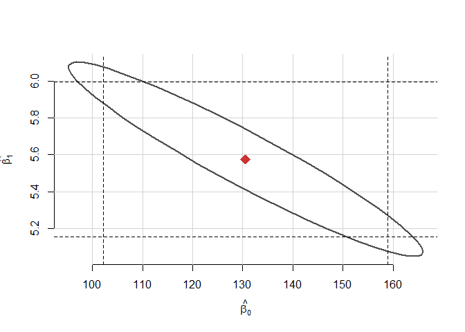

Se poate observa că regiunea de încredere $RC(\beta_0, \beta_1)$ evidențiază corelația dintre cei doi parametrii.

### 3.3.2 Predicție

Vom începe prin a da intervalul de încredere pentru răspunsul mediu care reiese din prima parte a Prop. :

Intervalul de încredere pentru $\mathbb{E}[y_i | x_i] = \beta_0 + \beta_1 x_i$ este
$$\left[\hat{y}_{i} - t_{n-2}(1-\alpha / 2) \hat{\sigma} \sqrt{\frac{1}{n}+\frac{\left(x_{i}-\bar{x}\right)^{2}}{\sum\left(x_{j}-\bar{x}\right)^{2}}}, \hat{y}_{i} + t_{n-2}(1-\alpha / 2) \hat{\sigma} \sqrt{\frac{1}{n}+\frac{\left(x_{i}-\bar{x}\right)^{2}}{\sum\left(x_{j}-\bar{x}\right)^{2}}}\right]$$
unde $t_{n-2}(1-\alpha / 2)$ este cuantila de ordin $1-\alpha/2$ a repartiției Student $t_{n-2}$.

Atunci când vorbim de predicție vom dori să determinăm un *interval de predicție* pentru valoarea rezultată din model. Se numește *interval de predicție* de nivel $1-\alpha$ pentru o variabilă aleatoare neobservată $Y$ date fiind datele $X$ intervalul aleator $\left[A(X), B(X)\right]$ care verifică

$$\mathbb{P}_{\theta}\left(A(X)\leq Y\leq B(X)\right)\geq 1-\alpha, \quad\forall \theta.$$

Se observă similaritatea dintre un interval de predicție și un interval de încredere, diferența fiind dată că un interval de predicție este un interval pentru o variabilă aleatoare și nu pentru un parametru (care este o constantă). Având în vedere variabilitatea v.a. $Y$ este de așteptat ca intervalul de predicție să fie mai mare dacât cel de încredere la același nivel de încredere.

În cazul modelului gaussian (termenii eroare sunt repartizați normal), observăm, ținând cont de liniaritatea lui $\hat y_{n+1}$ în $\hat\beta_0$, $\hat\beta_1$ și $\varepsilon_{n+1}$, că

$$y_{n+1}-\hat{y}_{n+1} \sim \mathcal{N}\left(0, \sigma^{2}\left(1+\frac{1}{n}+\frac{\left(x_{n+1}-\bar{x}\right)^{2}}{\sum\left(x_{i}-\bar{x}\right)^{2}}\right)\right)$$

și cum varianța $\sigma^2$ nu este cunoscută în general aceasta este estimată prin $\hat\sigma^2$. De asemenea, notând că variabilele aleatoare $y_{n+1}-\hat{y}_{n+1}$ și $\frac{(n-2)\hat\sigma^2}{\sigma^2}$ sunt independente avem următorul rezultat referitor la intervalul de predicție.

Avem că
$$\frac{y_{n+1}-\hat{y}_{n+1}}{\hat{\sigma} \sqrt{1+\frac{1}{n}+\frac{\left(x_{n+1}-\bar{x}\right)^{2}}{\sum\left(x_{i}-\bar{x}\right)^{2}}}} \sim t_{n-2}$$
ceea ce conduce la un interval de predicție de nivel $1-\alpha$ pentru $y_{n+1}$
$$\left[\hat{y}_{n+1} \pm t_{n-2}(1-\alpha / 2) \hat{\sigma} \sqrt{1+\frac{1}{n}+\frac{\left(x_{n+1}-\bar{x}\right)^{2}}{\sum\left(x_{i}-\bar{x}\right)^{2}}}\right],$$
unde $t_{n-2}(1-\alpha / 2)$ este cuantila de ordin $1-\alpha/2$ a repartiției Student $t_{n-2}$.

Observăm că pe măsură ce punctul de prezis admite o abscisă $x_{n+1}$ mai depărtată de media $\bar x$ cu atât intervalul de predicție este mai mare. Mai mult, putem constata că atunci când $x_{n+1}$ variază, curba descrisă de capetele intervalului este o hiperbolă de axe $x = \bar x$ și $y = \hat\beta_0 + \hat\beta_1 x$. Pentru a observa acest lucru putem face schimbarea de varaibile $u = x - \bar x$ și $v = y - \hat\beta_0 + \hat\beta_1 x)$ de unde concluzionăm că un punct de coordonate $(u,v)$ se află în regiunea de mai sus dacă

$$\frac{u^2}{a^2} - \frac{v^2}{b^2}\leq 1$$

unde $a^2 = \left(1+\frac{1}{n}\right) \sum\left(x_{i}-\bar{x}\right)^{2}$ și $b^2 = \left(1+\frac{1}{n}\right)\left(t_{n-2}(1-\alpha / 2) \hat{\sigma}\right)^{2}$. În mod similar se poate arăta și că forma curbei descrisă de capetele intervalului de încredere a răspunsului mediu este tot o hiperbolă.

De asemenea sunt multe circumstanțele în care am dori să avem intervalele de încredere pentru răspunsul mediu respectiv intervalele de predicție în mai mult de un punct, prin urmare ne aflăm în cadrul unei probleme de inferență simultană. O soluție la această problemă, în cazul în care avem $m$ puncte, este dată de inegalitatea lui Bonferroni ($\mathbb{P}\left(\cup_{i=1}^n A_i\right)\leq \sum_{i=1}^{n}\mathbb{P}(A_i)$) care conduce la marginea

$$\hat{y}_{i} - t_{n-2}\left(1-\frac{\alpha}{2m}\right) \hat{\sigma} \sqrt{\frac{1}{n}+\frac{\left(x_{i}-\bar{x}\right)^{2}}{\sum\left(x_{j}-\bar{x}\right)^{2}}} \leq \beta_0 + \beta_1 x_{i}\leq \hat{y}_{i} + t_{n-2}\left(1-\frac{\alpha}{2m}\right) \hat{\sigma} \sqrt{\frac{1}{n}+\frac{\left(x_{i}-\bar{x}\right)^{2}}{\sum\left(x_{j}-\bar{x}\right)^{2}}}$$
pentru răspunsul mediu $\mathbb{E}[y_{i}|x_{i}] = \beta_0 + \beta_1 x_{i}$, $i\in\{n+1,\ldots, n+m\}$, iar

$$\hat{y}_{i} - t_{n-2}\left(1-\frac{\alpha}{2m}\right) \hat{\sigma} \sqrt{1 + \frac{1}{n}+\frac{\left(x_{i}-\bar{x}\right)^{2}}{\sum\left(x_{j}-\bar{x}\right)^{2}}} \leq y_{i}\leq \hat{y}_{i} + t_{n-2}\left(1-\frac{\alpha}{2m}\right) \hat{\sigma} \sqrt{1 + \frac{1}{n}+\frac{\left(x_{i}-\bar{x}\right)^{2}}{\sum\left(x_{j}-\bar{x}\right)^{2}}}$$

pentru valoarea prezisă $y_i$, $i\in\{n+1,\ldots, n+m\}$ conform modelului, unde $t_{n-2}(1-\alpha / {2m})$ este cuantila de ordin $1-\alpha/{2m}$ a repartiției Student $t_{n-2}$. Marginea de mai sus este adevărată pentru $m$ puncte dar dacă am să găsim o relație similară pentru orice $x$ atunci această metodă nu ar mai putea fi aplicată. Scheffe a propus următoarea margină numită și banda lui Scheffe:

În contextul problemei de regresie liniare simple cu erori repartizare gaussian are loc următoarea relație, pentru răspunsul mediu
$$\mathbb{P}\left(\hat{y} - M_{\alpha} \hat{\sigma} \sqrt{\frac{1}{n}+\frac{\left(x-\bar{x}\right)^{2}}{\sum\left(x_{j}-\bar{x}\right)^{2}}} \leq \beta_0 + \beta_1 x\leq \hat{y} + M_{\alpha} \hat{\sigma} \sqrt{\frac{1}{n}+\frac{\left(x-\bar{x}\right)^{2}}{\sum\left(x_{j}-\bar{x}\right)^{2}}}, \quad \forall x\right) \geq 1-\alpha$$
și pentru valorile prezise
$$\mathbb{P}\left(\hat{y} - M_{\alpha} \hat{\sigma} \sqrt{1+\frac{1}{n}+\frac{\left(x-\bar{x}\right)^{2}}{\sum\left(x_{j}-\bar{x}\right)^{2}}} \leq y\leq \hat{y} + M_{\alpha} \hat{\sigma} \sqrt{1+\frac{1}{n}+\frac{\left(x-\bar{x}\right)^{2}}{\sum\left(x_{j}-\bar{x}\right)^{2}}}, \quad \forall x\right) \geq 1-\alpha$$
unde $M_{\alpha} = \sqrt{2F_{2, n-2}(1-\alpha)}$ iar $F_{2, n-2}(1-\alpha)$ este cuantila de ordin $1-\alpha$ a repartiției Fisher-Snedecor $F_{2, n-2}$.

> *Exemplu: prețul chiriilor în Munchen*

În figura de mai jos avem ilustrate intervalele de încredere pentru răspunsul mediu (cu portacaliu) și respectiv intervalele de predicție (cu roșu) pentru cele patru valori ale variabilei explicative. Se poate observa diferența mare între incertitudinea dată de cele două intervale.

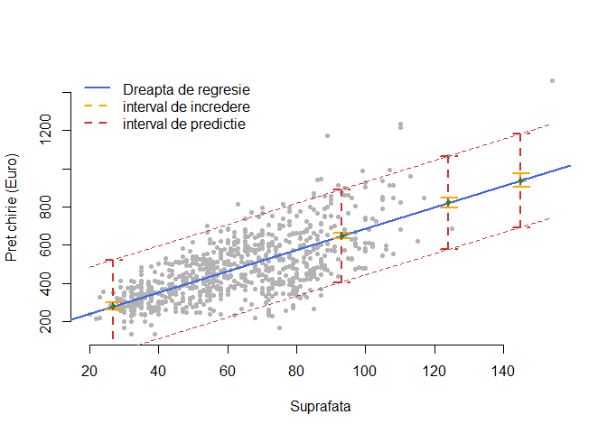

Dacă facem referire la răspunsul mediu și respectiv la valorile prezise atunci putem trasa banda de încredere corespunzătoare intervalelor de încredere din Prop. și respectiv banda lui Scheffe din Prop. :

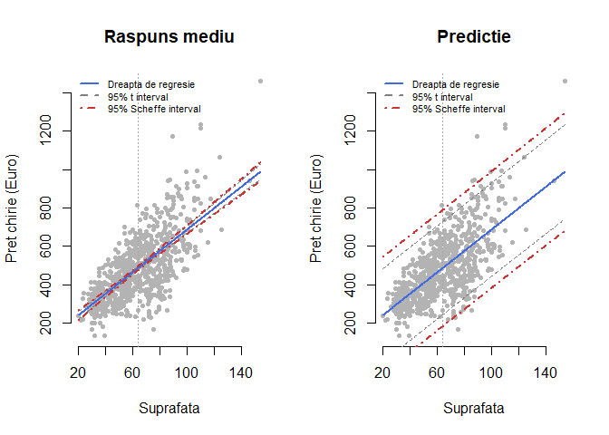

## 3.4 Aplicații numerice

Tabelul de mai prezintă o serie de date privind greutatea taților și respectiv a fiului lor cel mare

$$\begin{array}{lcccccccccccc}
Tata: & 65 & 63 & 67 & 64 & 68 & 62 & 70 & 66 & 68 & 67 & 69 & 71\\
Fiu: & 68 & 66 & 68 & 65 & 69 & 66 & 68 & 65 & 71 & 67 & 68 & 70
\end{array}$$

Obținem următoarele rezultate numerice

$$\sum_{i = 1}^{12}t_i = 800 \quad \sum_{i = 1}^{12}t_i^2 = 53418 \quad \sum_{i = 1}^{12}t_i f_i = 54107 \quad \sum_{i = 1}^{12}f_i = 811 \quad \sum_{i = 1}^{12}f_i^2 = 54849.$$

1. Determinați dreapta obținută prin metoda celor mai mici pătrate a greutății fiilor în funcie de greutatea taților.
2. Determinați dreapta obținută prin metoda celor mai mici pătrate a greutății taților în funcie de greutatea fiilor.
3. Arătați că produsul pantelor celor două drepte este egal cu pătratul coeficientului de corelație empirică dintre $t_i$ și $f_i$ (sau coeficientul de determinare).
1. Dreapta de regresie a greutății fiilor în funcție de greutatea taților este $f = \hat\alpha_0 + \hat\alpha_1 t$ unde coeficienții sunt dați de

$$\hat\alpha_0 = \bar f - \hat\alpha_1 \bar t, \quad \hat\alpha_1 = \frac{\sum_{i = 1}^{12}(t_i - \bar t)(f_i - \bar f)}{\sum_{i = 1}^{12}(t_i - \bar t)^2}$$

Pentru datele din problema noastră coeficienții sunt $\hat\alpha_0 = 35.8$ și $\hat\alpha_1 = 0.48$ iar dreapta de regresie este $f = 35.8 + 0.48 t$ (a se vedea figura din stânga).

2. Dreapta de regresie a greutății taților în funcție de greutatea fiilor este $t = \hat\beta_0 + \hat\beta_1 f$ unde coeficienții sunt dați de

$$\hat\beta_0 = \bar t - \hat\beta_1 \bar f, \quad \hat\beta_1 = \frac{\sum_{i = 1}^{12}(f_i - \bar f)(t_i - \bar t)}{\sum_{i = 1}^{12}(f_i - \bar f)^2}$$

3. Produsul pantelor celor două drepte este

$$\hat \alpha_1 \hat\beta_1 = \frac{\left[\sum_{i = 1}^{12}(f_i - \bar f)(t_i - \bar t)\right]^2}{\sum_{i = 1}^{12}(f_i - \bar f)^2\sum_{i = 1}^{12}(t_i - \bar t)^2}$$

și conform Prop. și a definiției coeficientului de determinare avem

$$\hat \alpha_1 \hat\beta_1 = r_{f,t}^2= R^2.$$

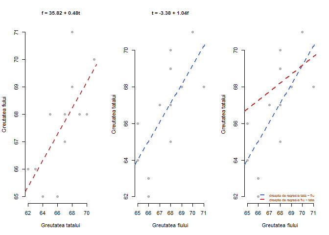

Dorim să exprimăm înălțimea $y$ (măsurată în picioare) a unui arbore în funcție de diametrul său $x$ (exprimat în centimetri) la înălțimea de 1m30 de la sol. Pentru aceasta dispunem de 20 de măsurători $(x_i,y_i)=$(diametru, înălțime) și în urma calculelor am obținut rezultatele următoare: $\bar x = 4.53$, $\bar y = 8.65$ și

$$\frac{1}{20}\sum_{i = 1}^{20}(x_i - \bar x)^2 = 10.97 \quad \frac{1}{20}\sum_{i = 1}^{20}(y_i - \bar y)^2 = 2.24 \quad \frac{1}{20}\sum_{i = 1}^{20}(x_i - \bar x)(y_i - \bar y) = 3.77.$$

1. Notăm cu $y = \hat \beta_0 + \hat \beta_1 x$ dreapta de regresie. Calculați coeficienții $\hat \beta_0$ și $\hat \beta_1$.
2. Dați și calculați o măsură care descrie calitatea concordanței datelor cu modelul propus.
3. Să presupunem că abaterile standard pentru estimatorii $\hat \beta_0$ și $\hat \beta_1$ sunt $\hat \sigma_0 = 1.62$ și respectiv $\hat \sigma_1 = 0.05$. Presupunem că erorile $\varepsilon_i$ sunt variabile aleatoare independente repartizare normal de medie $0$ și varianțe egale. Vrem să testăm ipotezele $H_0:\, \beta_j = 0$ versus $H_1:\, \beta_j \neq 0$ pentru $j = 0,1$. De ce acest test este interesant în contextul problemei noastre?
1. Estimatorii coeficienților dreptei de regresie $y = \hat \beta_0 + \hat \beta_1 x$ sunt dați de

$$\hat \beta_1 = \frac{\sum_{i = 1}^{n}(x_i - \bar x)(y_i - \bar y)}{\sum_{i = 1}^{n}(x_i - \bar x)^2} \approx 0.344$$

și respectiv

$$\hat \beta_0 = \bar y - \hat \beta_1 \bar x \approx 7.09$$

2. Pentru a măsura calitatea concordanței datelor la modelul de regresie vom folosi coeficientul de determinare $R^2$. Am văzut că acesta corespunde pătratului coeficientului de corelație empirică:

$$R^2 = r_{x,y}^2 = \left(\frac{\sum_{i = 1}^{n}(x_i - \bar x)(y_i - \bar y)}{\sqrt{\sum_{i = 1}^{n}(x_i - \bar x)^2}\sqrt{\sum_{i = 1}^{n}(y_i - \bar y)^2}}\right)^2 \approx 0.58.$$

Observăm că modelul de regresie liniară simplă explică un pic mai mult de jumătate din variabilitatea datelor.

3. Sub ipoteza modelului condiționat normal (erorile $\varepsilon_i$ sunt variabile aleatoare independente repartizare normal de medie $0$ și varianțe egale) avem că $\hat\beta_j\sim\mathcal{N}(\beta_j, \sigma_{\hat\beta_j}^2)$ și înlocuind varianțele $\sigma_{\hat\beta_j}^2$ cu estimatorii $\hat\sigma_j^2$, deducem că $\frac{\hat\beta_j - \beta_j}{\hat\sigma_j}\sim t_{n-2}$.

Prin urmare, sub $H_0$ avem că

$$\frac{\hat\beta_0}{\hat\sigma_0}\sim t_{18},$$

iar pentru un prag de semnificație $1-\alpha = 95\%$, ținând seama că $\left|\frac{\hat\beta_0}{\hat\sigma_0}\right|\approx 4.38$ și că $t_{18}(1-\alpha/2)\approx 2.1$, concluzionăm că respingem ipoteza nulă.

În mod similar, pentru $\hat\beta_1$ găsim că

$$\left|\frac{\hat\beta_1}{\hat\sigma_1}\right|\approx 6.88 > 2.1$$

de unde respingem ipoteza nulă $H_0:\, \beta_1 = 0$ în acest caz de asemenea.

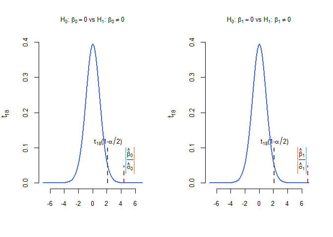

# 4 Modelul de regresie liniară multiplă

## 4.1 Introducere

Principiul problemei de regresie este de a modela relația dintre o variabilă $y$, numită variabilă răspuns sau variabilă dependentă (cea pe care vrem să o explicăm), cu ajutorul unei funcții care depinde de un anumit număr de variabile $\boldsymbol x = (x_1,\ldots, x_p)^\intercal$, numite variabile explicative, covariabile, predictori sau încă variabile independente (vom folosi în general primele trei denumiri)

$$y\approx g(\boldsymbol x) = g(x_1,\ldots, x_p).$$
În realitate, relația de mai sus nu este exactă (i.e. $\approx$) deoarece se află sub influența unei erori aleatoare $\varepsilon$. Presupunând că erorile sunt aditive avem o relație de tipul

$$y = g(x_1,\ldots, x_p) + \varepsilon.$$

Astfel având dat un eșantion de talie $n$ de $(p+1)$-upluri $(\boldsymbol x_i, y_i)$ cu $\boldsymbol x_i = (x_{i1},\ldots,x_{ip})^\intercal$, $i \in\{1,\ldots,n\}$, $n>p$, ne propunem să determinăm $g$, i.e. să separăm componenta sistematică $g$ (influența covariabilelor asupra răspunsului mediu) de termenul eroare $\varepsilon$ (incertitudinea modelului). Aproximarea, $\approx$, din relația anterioară se poate descrie matematic sub forma

$$g = \underset{f\in\mathcal{F}}{\arg\min}\sum_{i = 1}^{n}L\left(y_i - f(\boldsymbol x_i)\right)$$

unde $L(\cdot)$ se numește funcție de cost sau de pierdere ([loss function](https://en.wikipedia.org/wiki/Loss_function)) iar $\mathcal{F}$ este o clasă de funcții dată.

În general funcția de cost poate lua multe forme dar de cele mai multe ori vom întâlni două: funcția de cost absolut $L(u) = |u|$ sau funcția de cost pătratic $L(u) = u^2$.

În ceea ce privește clasa de funcții $\mathcal{F}$ ce descriu componenta sistematică a modelului, în contextul modelului liniar vom considera clasa de funcții liniare (i.e. componenta sistematică este o combinație liniară de covariabile)

$$\mathcal{F} = \left\{f:\mathbb{R}^p\to \mathbb{R}\,|\, f(\boldsymbol x) = \begin{pmatrix}1 & \boldsymbol x\end{pmatrix} \boldsymbol \beta = \beta_0 + \beta_1 x_1 +\cdots + \beta_p x_p\right\}.$$

Este important de menționat că atunci când vorbim de *regresie liniară* ne referim la liniaritatea în *parametrii modelului* $\beta_j$ și nu în variabilele explicative.

De exemplu, în contextul modelului de regresie liniară simplă, următoarele modele $y = \beta_0 + \beta_1 x^2 + \varepsilon$, $y = \beta_0 + \beta_1 \log(x) + \varepsilon$ și $y = \beta_0 + \beta_1 \left(x^3 - \cos(x)^2 + e^x\right) + \varepsilon$ sunt liniare chiar dacă variabila predictor $x$ poate prezenta un efect neliniar asupra răspunsului mediu. Pe de altă parte, modelul $y = \beta_0 + \beta_1 x^{\beta_2} + \varepsilon$ nu este un model liniar.

De asemenea, $f_1(x_1,x_2) = \beta_0 + \beta_1 x_1 + \beta_2 x_2$, $f_2(x_1, x_2) = \beta_0 + \beta_1 x_1 + \beta_2 x_2 + \beta_3 \underbrace{x_1 x_2}_{x_3}$ sau $f_3(x_1, x_2) = \beta_0 + \beta_1 x_1 + \beta_2 x_2 + \beta_3 \underbrace{x_1 x_2}_{x_3}+ \beta_4 \underbrace{x_1^2}_{x_4}+ \beta_5 \underbrace{x_2^3}_{x_5}$ sunt toate funcții liniare în $\boldsymbol\beta$.

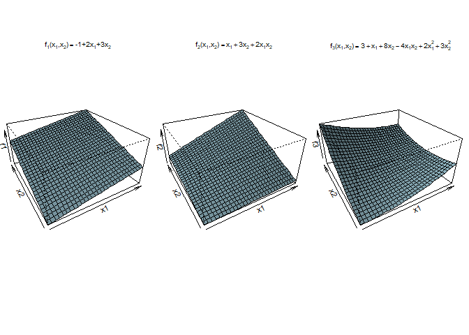

## 4.2 Modelare

Modelul de regresie liniară multiplă reprezintă o extensie a modelului de regresie liniară simplă atunci când numărul variabilelor explicative este finit (pentru mai multe detalii privind analiza de regresie se pot consulta monografiile (Seber and Lee 2003), (Rencher and Schaalje 2008), (Weisberg 2014) sau (Faraway 2015)).

Pentru a estima parametrii necunoscuți $\boldsymbol\beta$, colectăm datele $(y_i, \boldsymbol x_i)$ și presupunem că acestea verifică modelul

$$y_i = \beta_0 + \beta_1 x_{i1} + \cdots + \beta_p x_{ip} + \varepsilon_i, \quad i = 1,2,\ldots,n$$
unde

- $x_{ij}$ sunt valori cunoscute și nu sunt aleatoare
- parametrii $\beta_j$ sunt necunoscuți și nu sunt aleatori
- $\varepsilon_i$ sunt variabile aleatoare necunoscute

Scris sub formă compactă (matriceală) modelul devine

$$\boldsymbol Y = \boldsymbol X\boldsymbol \beta + \boldsymbol \varepsilon$$

unde

- $\mathbf{X}$ se numește *matricea de design*

$$\mathbf{X}=\begin{pmatrix}
1 & x_{11} & \cdots & x_{1p}\\
\vdots & \vdots & \ddots & \vdots\\
1 & x_{n1} & \cdots & x_{np}
\end{pmatrix}_{n\times(p+1)}$$

- $\mathbf{Y}$ este *vectorul răspuns* și este un vector aleator, $\boldsymbol\beta$ este *vectorul parametrilor* sau coeficienților și este necunoscut iar $\boldsymbol\varepsilon$ este *vectorul erorilor* și este un vector aleator

$$\mathbf{Y}=\begin{pmatrix}
y_1 \\
\vdots \\
y_n
\end{pmatrix}_{n\times 1},\quad\boldsymbol\beta=\begin{pmatrix}
\beta_0 \\
\beta_1 \\
\vdots \\
\beta_p
\end{pmatrix}_{(p+1)\times 1}\text{ și }\quad
\boldsymbol\varepsilon=\begin{pmatrix}
\varepsilon_1 \\
\vdots \\
\varepsilon_n
\end{pmatrix}_{n\times 1}.$$

Coloana cu termeni de $1$ din matricea de design $\boldsymbol X$ corespunde termenului liber (ordonatei la origine - intercept). Un model foarte simplu, numit și *modelul nul* este cel în care nu apar variabile explicative $\boldsymbol Y = \boldsymbol \mu + \boldsymbol \varepsilon$:

$$\begin{pmatrix}
y_1 \\
\vdots \\
y_n
\end{pmatrix}_{n\times 1} = \begin{pmatrix}
\mu_1 \\
\vdots \\
\mu_n
\end{pmatrix}_{n\times 1} + \begin{pmatrix}
\varepsilon_1 \\
\vdots \\
\varepsilon_n
\end{pmatrix}_{n\times 1}.$$

În cele ce urmează vom presupune că matricea de design $\boldsymbol X$ are rangul $rang(\boldsymbol X) = p+1$ acest fapt implicând că vectorii coloană sunt liniar independenți. O condiție necesară pentru această ipoteză este ca talia eșantionului $n$ să fie mai mare decât numărul de covariabile din model. Această presupunere este necesară pentru a estima în mod unic coeficienții modelului. În cazul în care matricea de design nu este de rang $p+1$ atunci ne confruntăm cu o problemă de identifiabilitate a modelului.

Un model de regresie liniară multiplă este definit de relația

$$\boldsymbol Y = \boldsymbol X\boldsymbol \beta + \boldsymbol \varepsilon$$

unde

- $\boldsymbol Y$ este un vector aleator de dimensiune $n$
- $\boldsymbol X$ este o matrice de dimensiune $n\times(p+1)$ numită matrice de design
- $\boldsymbol\beta$ este un vector de dimensiune $p+1$ de parametrii necunoscuți ai modelului
- $\boldsymbol\varepsilon$ este vectorul aleator centrat al erorilor

Pentru a specifica în totalitate *modelul clasic de regresie liniară* trebuie să facem următoarele ipoteze referitoare la componenta sistematică a modelului și la vectorul eroare. În primul rând, dacă ne raportăm la tipul variabilelor explicative sau la tipul de experiment care a condus la observarea datelor (e.g. experiment planificat), putem distinge între două situații: covariabilele sunt deterministe, cum este cazul unui plan de experiență planificat, sau sunt aleatoare atunci când avem de-a face cu date observaționale. În cel de-al doilea caz, când regresorii sunt aleatori, datele trebuie înțelese ca realizări ale unui vector aleator iar modelul trebuie văzut ca unul condiționat (la matricea de design $\boldsymbol X = x$), a se vedea secțiunea de Introducere.

În al doilea rând, dacă facem referire la termenii eroare $\varepsilon_i$ (cei care descriu incertitudinea modelului) aceștia trebuie să fie de medie $0$, $\mathbb{E}[\varepsilon_i] = 0$ sau sub formă matriceală $\mathbb{E}[\boldsymbol \varepsilon] = 0$, să aibă varianță constantă (homoscedasticitate) $Var(\varepsilon_i) = \sigma^2$ și să fie necorelate $Cov(\varepsilon_i, \varepsilon_j) = 0$ pentru $i\neq j$. Ipoteza de homoscedasticitate și necorelare poate fi scrisă sub forma matriceală $Cov(\boldsymbol\varepsilon) = Var(\boldsymbol\varepsilon) = \mathbb{E}[\boldsymbol\varepsilon\boldsymbol\varepsilon^\intercal] = \sigma^2 I_n$. Să remarcăm că în contextul modelului condiționat aceste ipoteze se scriu sub forma $\mathbb{E}[\boldsymbol\varepsilon|\boldsymbol X] = 0$ și respectiv $Cov(\boldsymbol\varepsilon|\boldsymbol X) = \sigma^2 I_n$ dar pentru ușurință vom elimina condiționarea din notație aceasta fiind subînțeleasă din context.

Sumarizând, ipotezele modelului de regresie liniară multiplă sunt:

$$(\mathcal{H})\left\{\begin{array}{ll}
\mathcal{H}_1: \, rang(\boldsymbol X) = p+1\\
\mathcal{H}_2: \, \mathbb{E}[\boldsymbol \varepsilon] = 0,\, Var(\boldsymbol \varepsilon) = \sigma^2 I_n
\end{array}\right.$$

Prima ipoteză ne spune că matricea de design $\boldsymbol X$ are coloanele liniar independente iar a doua ipoteză se referă la centralitatea erorilor (medie nulă), homoscedasticitatea (aceeași varianță) și necorelarea acestora.

Înainte de a trece la o discuție asupra ipotezelor modelului de regresie liniară multiplă vom introduce o serie de notații utile în cele ce vor urma. Pentru a face disticția dintre parametrii modelului $\boldsymbol\beta$ și $\sigma^2$ și estimatorii lor vom folosi, ca de obicei, notația cu căciulă, respectiv $\hat{\boldsymbol\beta}$ și $\hat\sigma^2$, în general fiind imposibil să determinăm valorile adevărate ale parametrilor. Folosind $\hat{\boldsymbol\beta}$ ca estimator al lui $\boldsymbol\beta$ putem determina cu ușurință estimatorul $\widehat{\mathbb{E}[y_i]}$ al mediei lui $y_i$,

$$\widehat{\mathbb{E}[y_i]} = \hat{\beta}_0 + \hat{\beta}_1 x_{i1} + \cdots + \hat{\beta}_p x_{ip} = \boldsymbol x_i^\intercal\hat{\boldsymbol\beta},$$

unde am considerat $\boldsymbol x_i^\intercal=(1,x_{i1},\ldots,x_{ip})$. Acest estimator, numit și valoare ajustată, se mai notează și cu $\hat y_i$, i.e. $\hat y_i = \widehat{\mathbb{E}[y_i]}$ iar eroare estimată, adică diferența dintre valoarea reală $y_i$ și cea estimată $\hat y_i$, se numește valoare reziduală și se notează cu $\hat\varepsilon_i = y_i - \hat y_i = y_i - \boldsymbol x_i^\intercal\hat{\boldsymbol\beta}$. Este important de notat că valorile reziduale (reziduurile) $\hat\varepsilon_i$ nu sunt identice cu termenii eroare $\varepsilon_i$ ei pot fi interpretați ca estimări (sau mai precis predicții) ai acestora, care, ca și vectorul de parametrii $\boldsymbol\beta$, sunt necunoscuți. Reziduurile conțin variabialitatea din date (incertitudinea modelului) care nu poate fi explicată prin intermediul variabilelor explicative.

### 4.2.1 Liniaritatea efectelor variabilelor explicative

Chiar dacă într-o primă etapă ipoteza de liniaritate a efectelor covariabilelor pare o ipoteză restrictivă, am văzut că modelul de regresie liniară permite și relații neliniare. Spre exemplu, dacă luăm în considerare următorul model de regresie în care covariabila $z_i$ admite un efect logaritmic,

$$y_i = \beta_0 + \beta_1 \log(z_i) + \varepsilon_i$$

atunci definind variabila $x_i=\log(z_i)$ regăsim un model de regresie liniară simplă $y_i = \beta_0 + \beta_1 x_i + \varepsilon_i$. Trebuie menționat că într-un model de regresie liniară putem avea relații neliniare între variabila răspuns și predictori atât timp cât este păstrată liniaritatea în parametrii modelului. Pentru modelare realațiilor neliniare vom prezenta în secțiunea Interpretarea efectului variabilelor explicative două abordări: una bazată pe transformarea variabilelor explicative și cealaltă prin intermediul polinoamelor.

> *Exemplu: înălțimea arborilor de eucalipt*

În acest exemplu facem referire la setul de date `Eucalypt` (care poate fi descărcat de aici) și dorim să modelăm relația dintre înălțimea (medie) arborilor de eucalipt și circumferința acestora. Modelul de regresie liniară simplă este dat de

$$ht_i = \beta_0 + \beta_1 circ_i + \varepsilon_i, \quad i =1,\ldots, 1429$$

care, prin aplicarea metodei celor mai mici pătrate, conduce la etimatorii $\hat\beta_0 =9.037$ și respectiv $\hat\beta_1 =0.257$ pentru coeficienții modelului și astfel

$$\widehat{ht}_i = 9.037 + 0.257 circ_i, \quad i =1,\ldots, 1429.$$

Observăm că pentru o creștere în circumferință de un $1$ cm avem o creștere medie în înălțime de 25.7 cm. De asemenea putem remarca din figura de mai jos imaginea din stânga, că pentru valori mici ale circumferinței arborilor acestea se regăsesc sub dreapta de regresie ceea ce sugerează o relație neliniară între înălțime și circumferință. Astfel, putem considera un model simplu de tipul

$$ht_i = \beta_0 + \beta_1 \sqrt{circ_i} + \varepsilon_i,$$

care ar conduce la o mai bună ajustare pe date (coeficientul de determinare $R^2=0.7820638$ este un pic mai mare față de cel din modelul de regresie simplă $R^2=0.7683202$) și la estimatorii $\hat\beta_0 =-2.73$ și respectiv $\hat\beta_1 =3.494$,

$$\widehat{ht}_i = -2.73 + 3.494 \sqrt{circ_i}, \quad i =1,\ldots, 1429. \quad\square$$

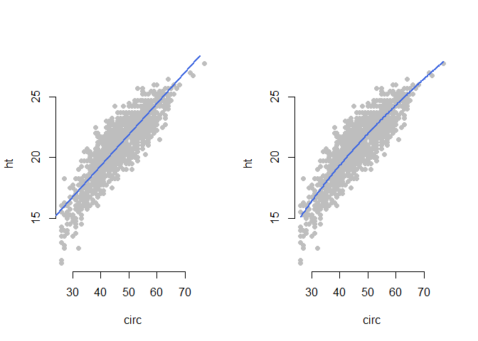

> *Exemplu: prețul chiriilor din Munchen*

Raportându-ne la setul de date referitor la prețul chiriilor în Munchen pentru apartamentele dintr-o locație medie, construite după anul 1966 (date ce pot fi descărcate de aici) observăm că modelul de regresie liniară simplă dintre prețul chiriilor pe metru pătrat și suprafață

$$pret{\_m^2}_i = \beta_0 + \beta_1 suprafata_i + \varepsilon_i$$

devine în urma estimării

$$pret{\_m^2}_i = 10.52 - 0.041 suprafata_i + \varepsilon_i$$

ceea ce ar sugera că o relație neliniară între variabila răspuns și variabila explicativă ar fi mai potrivită (același lucru se observă și din imaginea din stânga a figurii de mai jos). O mai bună ajustare pe date se poate obține definind variabila explicativă $x = \frac{1}{suprafata}$ care ar conduce la modelul de regresie

$$pret{\_m^2}_i = \beta_0 + \beta_1 \frac{1}{suprafata_i} + \varepsilon_i.$$

Aplicând metoda celor mai mici pătrate obținem

$$\widehat{pret{\_m^2}_i} = \hat\beta_0 + \hat\beta_1 \frac{1}{suprafata_i} = 5.438 + 139.269 \frac{1}{suprafata_i}$$

ceea ce arată că prețul mediu pe $m^2$ scade neliniar odată cu creșterea suprafeței apartamentului (a se vedea imaginea din dreapta din figura de mai jos în care putem constata o mai bună ajustare a modelului pe date). De exemplu, diferența în medie dintre prețul pe $m^2$ al unui apartament de $35\,m^2$ față de unul de $36\,m^2$ este

$$\widehat{pret{\_m^2}}(35) - \widehat{pret{\_m^2}}(36) = \frac{139.269}{35} - \frac{139.269}{36} \approx 0.110531 \,\,Euro\quad \square$$

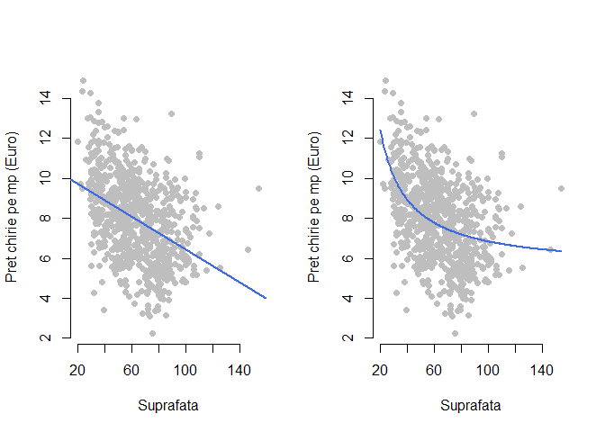

### 4.2.2 Homoscedasticitatea termenilor eroare

Proprietatea de homoscedasticitate a erorilor (ipoteza $\mathcal{H}_2$) presupune că varianța lui $\varepsilon_i$ nu variază în mod sistematic odată cu creșterea sau descreșterea valorilor variabilelor explicative. În figura de mai jos avem ilustrat un model simulat homoscedastic după relația $y_i\sim\mathcal{N}(-1 + 3x_i, 1)$ unde $x_i\sim\mathcal{U}[-5, 5]$ împreună cu dreapta de regresie (figura din stânga). Se poate constata că observațiile fluctuează constant în jurul dreptei de regresie (mediei), aceeași concluzie putând fi trasă și din examinarea graficului în care apar termenii eroare (figura din mijloc). Cum datele sunt simulate și cunoaștem adevăratul model (cunoaștem adevăratele valori ale coeficienților), termenii eroare sunt $\varepsilon_i = y_i - \boldsymbol x_i^\intercal\boldsymbol\beta$ și se cunosc. În general, vom folosi valorile reziduale pentru a estima termenii eroare $\hat\varepsilon_i = y_i - \boldsymbol x_i^\intercal\hat{\boldsymbol\beta}$ și pentru a verifica proprietate de homoscedasticitate a erorilor (figura din dreapta). Vom vedea, că atât termenii eroare cât și valorile reziduale au medie zero dar spre deosebire de termenii eroare, reziduurile pot avea varianțe diferite și în plus sunt corelate.

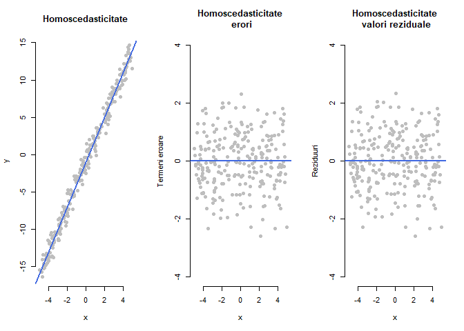

Un exemplu, des întâlnit în practică, de situație în care termenii eroare sunt heteroscedastici este ilustrat în figura următoare. Modelul folosit pentru generarea observațiilor este $y_i\sim\mathcal{N}\left(-1 + 3x_i, \left(1.2 + 0.5(x_i + 1)\right)^2\right)$ unde $x_i\sim\mathcal{U}[-5, 5]$. Se poate constata că pe măsură ce $x$ crește, variabilitatea observațiilor în jurul dreptei de regresie crește de asemenea (figura din stânga). Acest fenomen (de pâlnie) se poate observa cu mai mare ușurință atunci când trasăm graficul erorilor (respectiv valorilor reziduale).

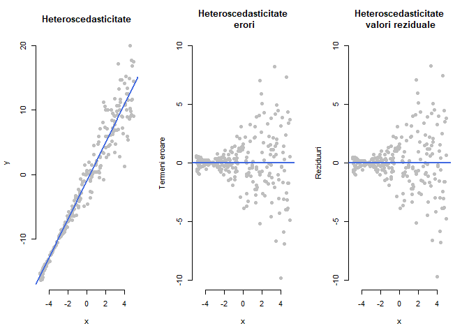

Conform teoriei, dacă modelul de regresie este corect (componenta sistematică a modelului este cea reală) și ipotezele modelului sunt verificate atunci toate graficele care implică valorile reziduale ($\hat\varepsilon$) versus orice funcție ce depinde de covariabile (sau de o combinație liniară a acestora) ar trebui să ilustreze o variație simetrică și constantă pe verticală ($\hat\varepsilon$), prin urmare este recomandată inspectarea a cât mai multor astfel de grafice. Cele mai uzuale grafice de reziduuri (*residual plots*) sunt cele care implică valorile reziduale $\hat\varepsilon_i$ și variabilele explicative $x_i$ care sunt incluse în modelul propus (sau nu - în acest caz orice structură observată în grafic poate sugera includerea covariabilei în model) respectiv valorile ajustate $\hat y_i$. Acest din urmă grafic de diagnostic ($\hat\varepsilon_i$ vs $\hat y_i$) este și cel mai des folosit în practică deoarece conține informații de la toate covariabilele incluse în model (Faraway 2015). Aceste grafice permit de asemenea detectarea neliniarității în componenta sistematică, de structură, a modelului.

Este important de menționat că sunt multe situațiile (i.e. atunci când avem de-a face cu un model neliniar) în care nu putem trage o concluzie asupra ipotezelor modelului doar privind comportamentul valorilor reziduale. De cele mai multe ori trebuie să avem grijă ca modelul specificat să fie corect. Următorul exemplu sugerează acest fapt:

> *Exemplu: importanța corectitudinii modelului - date simulate*

Acest exemplu este preluat din (Cook and Weisberg 1999) și evidențiază importanța corectitudinii modelului atunci când este evaluat un grafic al reziduurilor. În figura de mai jos avem ilustrat grafic diagrama de împrăștiere a punctelor precum și evoluția valorilor reziduale în raport cu valorile ajustate pentru modelul de regresie liniară multiplă:

$$y_i = \beta_0 + \beta_1 x_{i1} + \beta_2 x_{i2} + \varepsilon_i$$

unde observațiile au fost simulate artificial ($n = 500$). Efectul de pâlnie al reziduurilor (figura din dreapta) sugerează heteroscedasticitatea termenilor eroare în modelul propus, atât timp cât acest model este valid.

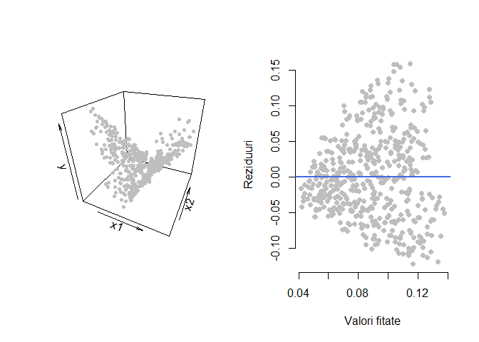

Dacă ne uităm la diagramele de împrăștiere pentru fiecare variabilă în parte (matricea diagramelor de împrăștiere - scatterplot matrix) observăm că variabilele predictor $x_1$ și $x_2$ sunt necorelate (coeficientul de corelație este -0.042) și sunt generate sferic (mai exact repartiția comună a predictorilor face parte din clasa repartițiilor elitice simetice - $\mathbb{E}[x_i|x_j]\approx \alpha_0 + \alpha_1 x_j$).

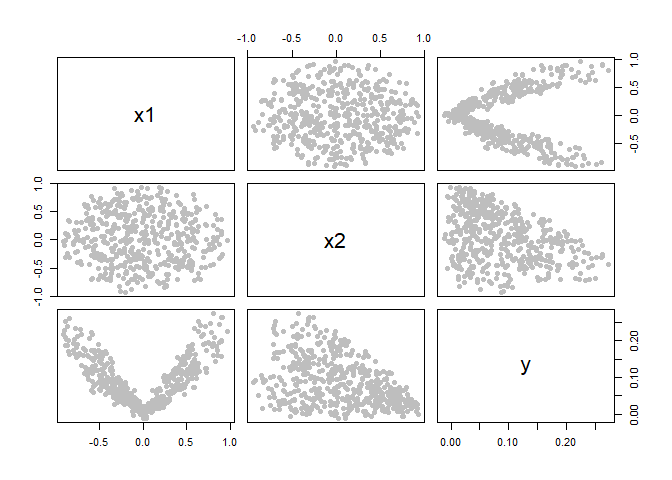

Problema care apare este că modelul de regresie este specificat greșit, componenta sistematică a modelului nu este liniară sau o funcție care să depindă de o combinație liniară de covariabile (i.e. $g(\boldsymbol x^\intercal \boldsymbol\beta)$), chiar dacă din graficul valorilor reziduale am crede că avem o problemă cu heteroscedasticitatea erorii. În acest exemplu particular, în care avem doar doi predictori, se putea observa, prin trasarea diagramei de împrăștiere în trei dimensiuni (figura de mai sus - stânga), că răspunsul mediu nu depinde liniar de $x_1$ și $x_2$ (în general există metode mai complexe de tipul *sliced inverse regression*). Acest lucru putea fi remarcat și prin trasarea valorilor reziduuale în raport cu fiecare variabilă explicativă în parte.

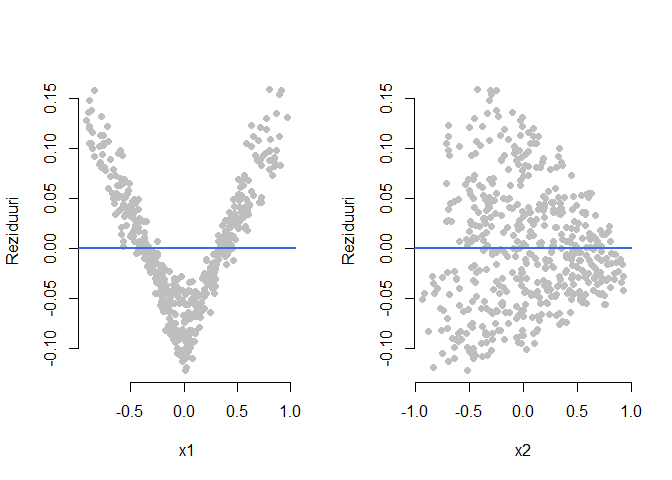

Trebuie menționat că datele au fost generate după următorul model:

$$y = \underbrace{\frac{|x_1|}{2 + (1.5 + x_2)^2}}_{=\mathbb{E}[y|x_1, x_2]} + \varepsilon$$

$$f_P(x_1,x_2) = \frac{\Gamma(m+2)}{\Gamma(m+1)\pi\sqrt{2}}(1 - x_1^2 - x_2^2)^m$$

unde $m>-1$ este un parametru de formă (pentru simulare am folosit $m = 0.5$). În figura de mai jos este ilustrată densitatea Pearson de tip II pentru mai multe valori ale parametrului de formă.

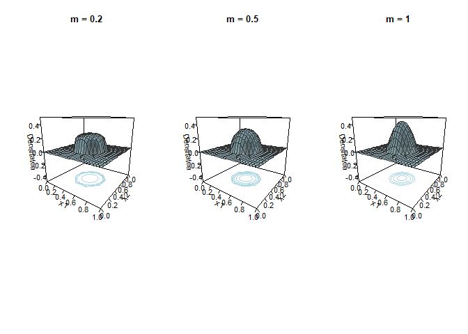

> *Exemplu: prețul chiriilor din Munchen*

În cazul setului de date ce face referire la prețul chiriilor din Munchen, dacă ne referim la relația dintre prețul net al chiriilor și suprafața de locuit (figura din stânga) constatăm o tendință de creștere a erorilor odată cu creșterea în suprafață a locuințelor (figura din stânga). Astfel, găsim că pentru suprafețe mai mari avem o plajă mai largă de valori ale prețurilor chiriilor.

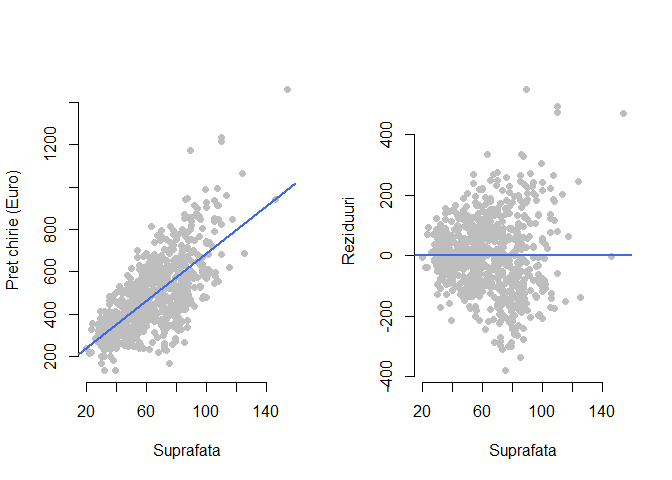

### 4.2.3 Necorelarea termenilor eroare

Ipoteza $\mathcal{H}_2$ presupune pe lângă homoscedasticitatea termenilor eroare și că aceștia sunt necorelați, i.e. $Cov(\varepsilon_i, \varepsilon_j)=0$ pentru $i\neq j$. Această ipoteză poate să nu fie conformă cu realitatea în special atunci când avem de-a face cu serii de timp sau date longitudinale (date care presupun eșantionarea acelorași unități de eșantionare la momente diferite de timp, e.g urmărirea și eșantionarea lunară a unor caracteristici de interes - viremia - pentru o serie de pacienți cu o boală gravă în vederea caracterizării stării imunității acestora). În aceste situații se observă o autocorelare a termenilor eroare. De exemplu, o autocorelare de ordin unu a termenilor eroare implică o relație liniară între eroarea la momentul $i$ și eroarea la momentul $i-1$, e.g. $\varepsilon_i = \rho \varepsilon_{i-1} + u_i$ unde $u_i$ sunt variabile aleatoare independente și indentic repartizate iar o autocorelare de ordin $k$ se scrie sub forma $\varepsilon_i = \sum_{t = 1}^{k}\rho_t\varepsilon_{i-t} + u_i$.

În figura de mai jos avem ilustrat un exemplu de model de regresie liniară simplă în care erorile prezintă o autocorelare (pozitivă) de ordinul 1. Modelul a fost generat după relația $y_i = -1 + 3x_i + \varepsilon_i$ unde $x_i\sim\mathcal{U}[-5,5]$ iar $\varepsilon_i = 0.9\varepsilon_{i-1} + u_i$ cu $u_i\sim\mathcal{N}(0, 0.5^2)$. Se observă că autocorelarea termenilor eroare este *pozitivă* deoarece un termen eroare pozitiv (negativ) este mai probabil să fie urmat tot de un termen pozitiv (negativ) - figura din dreapta.

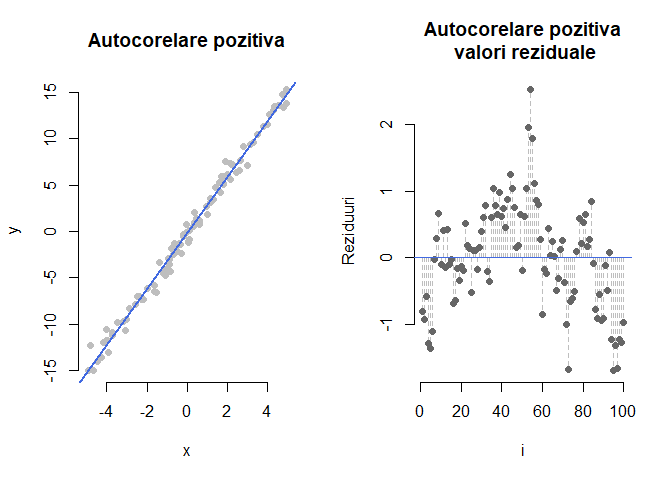

Următoarea figură ilustrează un exemplu clasic de autocorelare *negativă* a termenilor eroare. În această situație, termenii eroare pozitivi (negativi) sunt urmați cu precădere de termeni eroare negativi (pozitivi), prin urmare observăm frecvent o alternare a semnelor termenilor eroare. Modelul din figură este generat după relația $y_i = -1 + 3x_i + \varepsilon_i$ unde $x_i\sim\mathcal{U}[-5,5]$ iar $\varepsilon_i = -0.9\varepsilon_{i-1} + u_i$ cu $u_i\sim\mathcal{N}(0, 0.5^2)$.

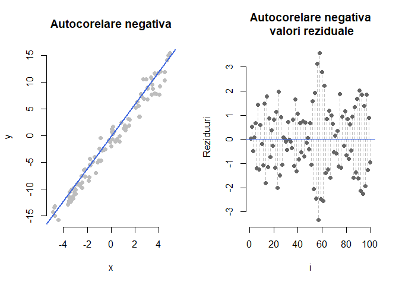

Dacă termenii eroare nu ar fi corelați ne-am aștepta ca graficul valorilor reziduale să prezinte o variație aleatoare în jurul dreptei orizontale $\varepsilon = 0$. O abordare alternativă de a investiga dacă erorile sunt corelate este de a trasa un grafic pentru perechile $(\hat\varepsilon_{i}, \hat\varepsilon_{i+1})$.

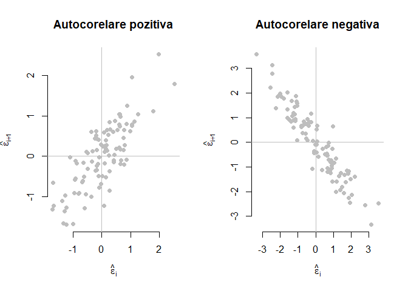

Autocorelarea erorilor apare de cele mai multe ori atunci când modelul de regresie nu este specificat corespunzător spre exemplu atunci când lipsește o variabilă explicativă din model sau efectul unei covariabile continue este neliniar. Cu toate acestea, sunt multe situațiile în care anumite variabile explicative care ar putea fi relevante pentru răspuns nu pot fi incluse în model deoarece nu au putut fi observate și în cazul în care acestea prezintă un caracter temporal ele pot induce o corelare a termenilor eroare. Vom ilustra acest fenomen printr-un exemplu simulat.

> *Exemplu: autocorelarea erorilor*

În figura de mai jos sunt ilustrate diagramele de împrăștiere a variabilelor explicative $x_1$ (stânga) și respectiv $x_2$ (mijloc) unde se poate observa că prima covariabilă prezintă un caracter temporal ($x_{i1} = \sum_{k = 1}^{i}a_k \sin(b_k)$ cu $a_k\sim\mathcal{N}(0, 0.7^2)$, $b_k\sim\mathcal{N}(0, 0.2^2)$ i.i.d și independente între ele) iar a doua fluctuează în jurul lui $0$ ($x_2\sim\mathcal{N}(0, 9)$). Variabila răspuns este generată după modelul $y_i = -1 + x_1 - 0.6x_2 + \varepsilon_i$ unde $\varepsilon_i\sim\mathcal{N}(0, 0.5^2)$ care verifică ipotezele unui model clasic de regresie liniară.

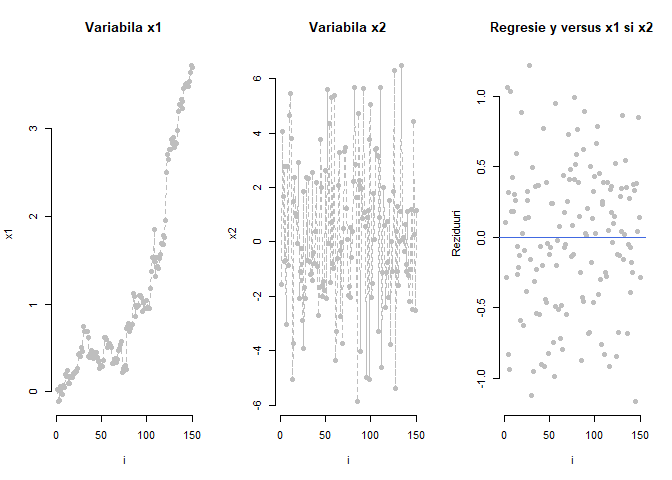

Modelul estimat obținut prin metoda celor mai mici pătrate este $\hat y_i = -0.997 + 1.031 x_1 -0.638 x_2$ iar graficul valorilor reziduale (figura de mai sus dreapta) nu prezintă niciun indiciu asupra autocorelării termenilor eroare.

Dacă presupunem că variabila predictor $x_2$ nu a fost observată atunci modelul de regresie liniară simplă estimat devine $\hat y_i = -1.237 + 1.064 x_1$ iar graficul valorilor reziduale este ilustrat în figura de mai jos (stânga). Chiar dacă variabila $x_2$ lipsește din model, coeficienții modelului ajustat (redus) sunt apropiați de valorile adevărate care au fost folosite pentru generarea datelor iar graficul valorilor reziduale prezintă același caracter aleator al erorilor.

În cazul în care variabila predictor $x_1$ nu a fost observată atunci modelul ajutat devine $\hat y_i = 0.179 -0.646 x_1$ dar în acest caz graficul reziduurilor prezintă o autocorelare a erorilor (figura din dreapta). Motivul pentru care apare acest fenomen este că variabila explicativă $x_1$ prezenta un caracter temporal pe când covariabila $x_2$ nu iar efectele acestora, $\beta_1 x_1$ respectiv $\beta_2 x_2$, au fost absorbite în termenul eroare. Mai exact, dacă variabila explicativă $x_1$ (respectiv $x_2$) este omisă din model atunci termenul eroare devine $\tilde\varepsilon = \beta_1 x_1 + \varepsilon$ (respectiv $\tilde\varepsilon = \beta_2 x_2 + \varepsilon$). Cum covariabila $x_2$ nu prezintă un trend temporal, efectul ei păstrează necorelarea termenului eroare. Pe de altă parte, atunci când efectul covariabilei $x_1$, care prezintă un trend temporal, este absorbit în termenul eroare acest fapt este reflectat în autocorelarea valorilor reziduale.

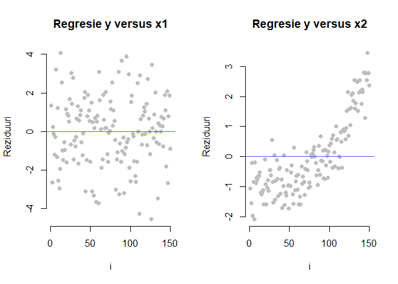